# Statistical model for predicting neonatal weight

Giulio Pratola

2026-04-13

# **Development of a predictive statistical model for neonatal weight.**

We obtained from **Neonatal Health Solutions** a dataset containing data from three hospitals managed by the company, with the goal of building a predictive model capable of estimating neonatal weight based on the variables included in the dataset.

## **Preliminary analysis variables descriptive study.**

Let’s load the dataset into a data frame and print the first rows to get an idea of the objects and variables we have.

```r
neonatalcare_data = read.csv("neonati.csv")

str(neonatalcare_data)
```

```
## 'data.frame':    2500 obs. of  10 variables:
##  $ Anni.madre  : int  26 21 34 28 20 32 26 25 22 23 ...
##  $ N.gravidanze: int  0 2 3 1 0 0 1 0 1 0 ...
##  $ Fumatrici   : int  0 0 0 0 0 0 0 0 0 0 ...
##  $ Gestazione  : int  42 39 38 41 38 40 39 40 40 41 ...
##  $ Peso        : int  3380 3150 3640 3690 3700 3200 3100 3580 3670 3700 ...
##  $ Lunghezza   : int  490 490 500 515 480 495 480 510 500 510 ...
##  $ Cranio      : int  325 345 375 365 335 340 345 349 335 362 ...
##  $ Tipo.parto  : chr  "Nat" "Nat" "Nat" "Nat" ...
##  $ Ospedale    : chr  "osp3" "osp1" "osp2" "osp2" ...
##  $ Sesso       : chr  "M" "F" "M" "M" ...
```

```r
head(neonatalcare_data)
```

```
##   Anni.madre N.gravidanze Fumatrici Gestazione Peso Lunghezza Cranio Tipo.parto
## 1         26            0         0         42 3380       490    325        Nat
## 2         21            2         0         39 3150       490    345        Nat
## 3         34            3         0         38 3640       500    375        Nat
## 4         28            1         0         41 3690       515    365        Nat
## 5         20            0         0         38 3700       480    335        Nat
## 6         32            0         0         40 3200       495    340        Nat
##   Ospedale Sesso
## 1     osp3     M
## 2     osp1     F
## 3     osp2     M
## 4     osp2     M
## 5     osp3     F
## 6     osp2     F
```

The data frame contains 2500 ovservations for 10 different variables. They concern records related to births that occurred in the company’s three hospitals, both for the newborn and for the mothers.

Specifically, we have raw information for:

- Anni.Madre - Mother’s age at the time of delivery - **Continuous quantitative variable on a ration scale;**
- N.gravidanze - Number of pregnancies the mother had priori to the delivery in question - **Discrete quantitative variable on a ratio scale;**
- Fumatrici - Observation regarding the mother’s smoking status. Recorded using No/Yes 0/1 scheme- **Categorical variable encoded on a nominal scale;**
- Gestazione - Gestation time of the fetus expressed in weeks - **Continuous quantitative variable on a ratio scale;**
- Peso - Newborn weight, measured at birth, expressed in grams - **Continuous quantitative variable on a ratio scale;**
- Lunghezza - Newborn length at birth, expressed in millimiters - **Continuous quantitative variable on a ratio scale;**
- Cranio - Newborn head diameter measured at birth, expressed in millimiters - **Continuous quantitative variable on a ratio scale;**
- Tipo.parto - Type of delivery of the newborn, Natural or Cesarean, indicated with “Nat” or “Ces” - **Categorical variable on a nominal scale;**
- Ospedale - Hospital where the delivery took place. Encoded as “osp1”, “osp2”, “osp3” - **Categorical variable on a nominal scale;**
- Sesso - Newborn sex - encoded as “M” for males and “F” for females - **Categorical variable on a nominal scale;**

Based on this preliminary analysis of variable types, we identify Peso as our **response variable**, while the others will be **explanatory variables** in our model.

#### **Variables Descriptive analysis.**

#### **Anni.madre:**

```r
attach(neonatalcare_data)

agen_distribution = table(Anni.madre)
agen_frtable = agen_distribution/sum(agen_distribution)
age_cumsum = cumsum(agen_distribution)
age_cumrel = age_cumsum/sum(agen_distribution)

final_agetable = cbind(ni=agen_distribution, fi=agen_frtable, Ni=age_cumsum, Fi=age_cumrel)
colnames(final_agetable) = c("Absolute Fr.", "Relative Fr.", "Cumulated absolute fr.", "Cumulated relative fr.")
knitr::kable(final_agetable)
```

|  | Absolute Fr. | Relative Fr. | Cumulated absolute fr. | Cumulated relative fr. |
| --- | --- | --- | --- | --- |
| 0 | 1 | 0.0004 | 1 | 0.0004 |
| 1 | 1 | 0.0004 | 2 | 0.0008 |
| 13 | 1 | 0.0004 | 3 | 0.0012 |
| 14 | 2 | 0.0008 | 5 | 0.0020 |
| 15 | 6 | 0.0024 | 11 | 0.0044 |
| 16 | 13 | 0.0052 | 24 | 0.0096 |
| 17 | 18 | 0.0072 | 42 | 0.0168 |
| 18 | 24 | 0.0096 | 66 | 0.0264 |
| 19 | 45 | 0.0180 | 111 | 0.0444 |
| 20 | 66 | 0.0264 | 177 | 0.0708 |
| 21 | 74 | 0.0296 | 251 | 0.1004 |
| 22 | 100 | 0.0400 | 351 | 0.1404 |
| 23 | 115 | 0.0460 | 466 | 0.1864 |
| 24 | 131 | 0.0524 | 597 | 0.2388 |
| 25 | 180 | 0.0720 | 777 | 0.3108 |
| 26 | 184 | 0.0736 | 961 | 0.3844 |
| 27 | 197 | 0.0788 | 1158 | 0.4632 |
| 28 | 172 | 0.0688 | 1330 | 0.5320 |
| 29 | 174 | 0.0696 | 1504 | 0.6016 |
| 30 | 200 | 0.0800 | 1704 | 0.6816 |
| 31 | 147 | 0.0588 | 1851 | 0.7404 |
| 32 | 159 | 0.0636 | 2010 | 0.8040 |
| 33 | 110 | 0.0440 | 2120 | 0.8480 |
| 34 | 96 | 0.0384 | 2216 | 0.8864 |
| 35 | 66 | 0.0264 | 2282 | 0.9128 |
| 36 | 64 | 0.0256 | 2346 | 0.9384 |
| 37 | 41 | 0.0164 | 2387 | 0.9548 |
| 38 | 38 | 0.0152 | 2425 | 0.9700 |
| 39 | 27 | 0.0108 | 2452 | 0.9808 |
| 40 | 19 | 0.0076 | 2471 | 0.9884 |
| 41 | 13 | 0.0052 | 2484 | 0.9936 |
| 42 | 8 | 0.0032 | 2492 | 0.9968 |
| 43 | 2 | 0.0008 | 2494 | 0.9976 |
| 44 | 4 | 0.0016 | 2498 | 0.9992 |
| 45 | 1 | 0.0004 | 2499 | 0.9996 |
| 46 | 1 | 0.0004 | 2500 | 1.0000 |

```r
summary(Anni.madre)
```

```
##    Min. 1st Qu.  Median    Mean 3rd Qu.    Max.
##    0.00   25.00   28.00   28.16   32.00   46.00
```

```r
library("moments")
mother_age_data = data.frame(
  Skewness = round(skewness(Anni.madre), 2),
  Kurtosis = round(kurtosis(Anni.madre)-3, 2),
  St_dev = round(sd(Anni.madre), 2)
)

knitr::kable((mother_age_data), "pipe")
```

| Skewness | Kurtosis | St_dev |
| --- | --- | --- |
| 0.04 | 0.38 | 5.27 |

Observing a summary of the measures of central tendency, variability and shape for anni.madre, as well as frequency table of the observations, we immediately notice two anomalous births recorded for this variable, maybe transcription errors, corresponding to mothers aged 0 and 1 year at delivery.

Proceed to plot the density curve of the distribution for anni.madre:

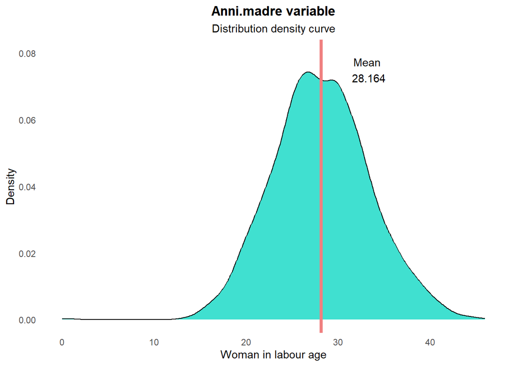

```r
library("ggplot2")
ggplot()+
  geom_density(aes(x=Anni.madre), col="black", fill="turquoise")+
  geom_vline(xintercept = mean(Anni.madre), linewidth=1.5, color = "lightcoral")+
  labs(x="Woman in labour age", y="Density", title = "Anni.madre variable", subtitle = "Distribution density curve")+
  geom_text(aes(x = mean(Anni.madre) + 5, y = 0.075, label = sprintf("Mean\n %.3f", mean(Anni.madre))), inherit.aes = FALSE) +
  ylim(0, 0.08)+
  theme_minimal()+
  theme(
    panel.grid = element_blank(),
    plot.title = element_text(hjust = 0.5, face = "bold"),
    plot.subtitle = element_text(hjust = 0.5)
  )
```

With a skewness of 0.04, the density curve of the anni.madre distribution shows an almost negligible positive skew, while a kurtosis of 0.38 indicates a leptokurtic curve.

#### **N.gravidanze:**

```r
birthn_distribution = table(N.gravidanze)
birthn_frtable = birthn_distribution/sum(birthn_distribution)
birth_cumsum = cumsum(birthn_distribution)
birth_cumrel = (birth_cumsum/sum(birthn_distribution))

final_birthtable = cbind(ni=birthn_distribution, fi=birthn_frtable, Ni=birth_cumsum, Fi=birth_cumrel)
colnames(final_birthtable) = c("Absolute Fr.", "Relative Fr.", "Cumulated absolute fr.", "Cumulated relative fr.")
knitr::kable(final_birthtable)
```

|  | Absolute Fr. | Relative Fr. | Cumulated absolute fr. | Cumulated relative fr. |
| --- | --- | --- | --- | --- |
| 0 | 1096 | 0.4384 | 1096 | 0.4384 |
| 1 | 818 | 0.3272 | 1914 | 0.7656 |
| 2 | 340 | 0.1360 | 2254 | 0.9016 |
| 3 | 150 | 0.0600 | 2404 | 0.9616 |
| 4 | 48 | 0.0192 | 2452 | 0.9808 |
| 5 | 21 | 0.0084 | 2473 | 0.9892 |
| 6 | 11 | 0.0044 | 2484 | 0.9936 |
| 7 | 1 | 0.0004 | 2485 | 0.9940 |
| 8 | 8 | 0.0032 | 2493 | 0.9972 |
| 9 | 2 | 0.0008 | 2495 | 0.9980 |
| 10 | 3 | 0.0012 | 2498 | 0.9992 |
| 11 | 1 | 0.0004 | 2499 | 0.9996 |
| 12 | 1 | 0.0004 | 2500 | 1.0000 |

```r
summary(N.gravidanze)
```

```
##    Min. 1st Qu.  Median    Mean 3rd Qu.    Max.
##  0.0000  0.0000  1.0000  0.9812  1.0000 12.0000
```

```r
prior_birth_data = data.frame(
  Skewness = round(skewness(N.gravidanze), 2),
  Kurtosis = round(kurtosis(N.gravidanze)-3, 2),
  St_dev = round(sd(N.gravidanze), 2)
)
knitr::kable((prior_birth_data), "pipe")
```

| Skewness | Kurtosis | St_dev |
| --- | --- | --- |
| 2.51 | 10.99 | 1.28 |

We expect a skewed right distribution, as indicated by a positive skewness of 2.51, with low values prevailing.

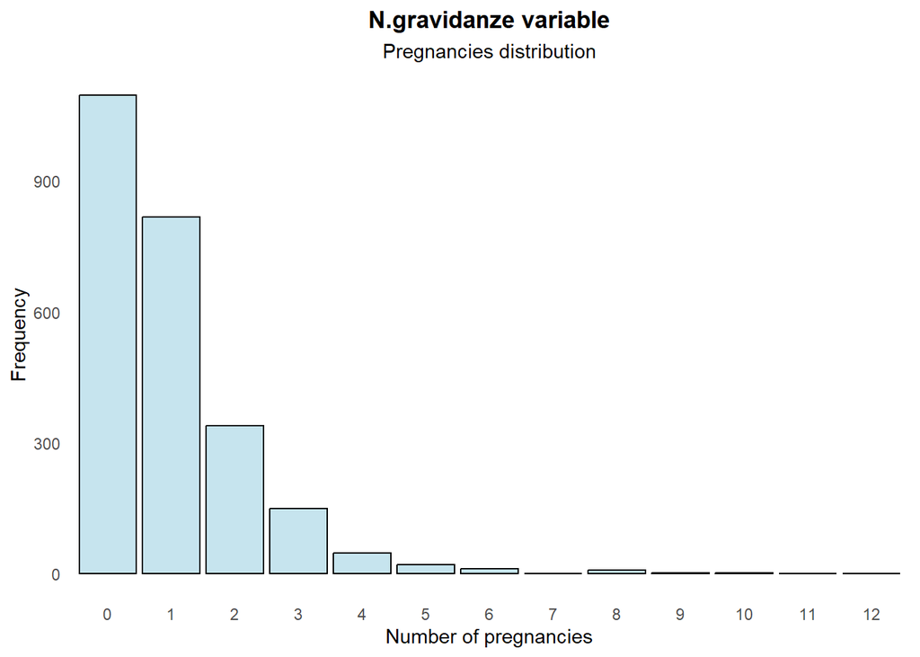

```r
ggplot() +
  geom_bar(
    aes(x = as.factor(N.gravidanze)),
    fill = "lightblue", color = "black", alpha = 0.7
  ) +
  labs(
    x = "Number of pregnancies",
    y = "Frequency",
    title = "N.gravidanze variable",
    subtitle = "Pregnancies distribution"
  ) +
  theme_minimal() +
  theme(
    panel.grid = element_blank(),
    plot.title = element_text(hjust = 0.5, face = "bold"),
    plot.subtitle = element_text(hjust = 0.5)
  )
```

Since this is a discrete variable, we use a barplot to visualize the distribution, obtaining graphical confirmation of the prevalence of 0 and 1 pregnancies in the total observations and of a strong positive skew.

#### **Fumatrici:**

```r
smokerstable = table(Fumatrici)
knitr::kable((smokerstable), "pipe")
```

| Fumatrici | Freq |
| --- | --- |
| 0 | 2396 |
| 1 | 104 |

```r
smokersperc = round((104*100)/2500, 2)
knitr::kable(smokersperc)
```

| x |
| --- |
| 4.16 |

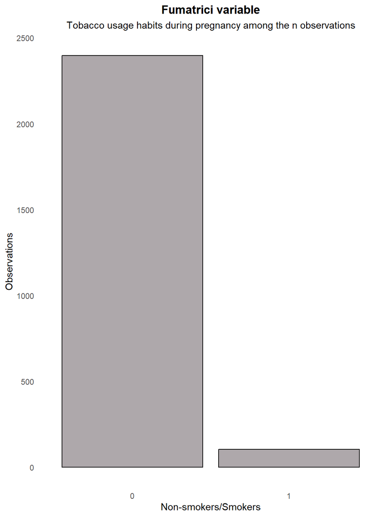

```r
ggplot() +
  geom_bar(
    aes(x = as.factor(Fumatrici)),
    fill = "lavenderblush4", color = "black", alpha = 0.7
  ) +
  labs(
    x = "Non-smokers/Smokers",
    y = "Observations",
    title = "Fumatrici variable",
    subtitle = "Tobacco usage habits during pregnancy among the n observations"
  ) +
  theme_minimal() +
  theme(
    panel.grid = element_blank(),
    plot.title = element_text(hjust = 0.5, face = "bold"),
    plot.subtitle = element_text(hjust = 0.5)
  )
```

For the variable Fumatrici, we observe 2396 non-smoking mothers versus 104 smoking mothers. As shown in the second table, the “fumatrici” value represents 4.16% of total observations.

We will leave more in-depth assessments to healthcare personnel; however [an information notice from the Ministry of Health](https://www.salute.gov.it/portale/fumo/dettaglioContenutiFumo.jsp?id=5583&area=fumo&menu=vuoto) dated 29 May 2024 indicates that children of smoking mothers have a 70% excess risk of lower respiratory tract diseases.

[A 2013 statistical survey](https://www.epicentro.iss.it/fumo/WTD2013Gravidanza) on a sample of n = 4953 women, conducted by the Istituto Superiore di Sanità, also found that within a subgroup where 23% were smokers, only 70% quit smoking during pregnancy, suggesting a potential underestimation of observations coded as 1 in our dataset. The study is not recent enough to be fully valid for 2024, but it may still indicate a tendency in the available data. A time series check from 2013 onward should be performed to determine whether the overall trend in smokers today is compatible with our dataset, comparing it to the reference population of the three hospitals and verifying whether local trends are correlated with national ones.

The same ISS report also notes positive effects on the prolonged mantenance of good health practices by mothers following pregnancy. Further study of this risk factor is recommended.

#### **Gestazione:**

```r
pln_distribution = table(Gestazione)
pln_frtable = pln_distribution/sum(pln_distribution)
pl_cumsum = cumsum(pln_distribution)
pl_cumrel = pl_cumsum/sum(pln_distribution)

final_pltable = cbind(ni=pln_distribution, fi=pln_frtable, Ni=pl_cumsum, Fi=pl_cumrel)
colnames(final_pltable) = c("Absolute Fr.", "Relative Fr.", "Cumulated absolute fr.", "Cumulated relative fr.")
knitr::kable(final_pltable)
```

|  | Absolute Fr. | Relative Fr. | Cumulated absolute fr. | Cumulated relative fr. |
| --- | --- | --- | --- | --- |
| 25 | 1 | 0.0004 | 1 | 0.0004 |
| 26 | 1 | 0.0004 | 2 | 0.0008 |
| 27 | 2 | 0.0008 | 4 | 0.0016 |
| 28 | 4 | 0.0016 | 8 | 0.0032 |
| 29 | 3 | 0.0012 | 11 | 0.0044 |
| 30 | 5 | 0.0020 | 16 | 0.0064 |
| 31 | 8 | 0.0032 | 24 | 0.0096 |
| 32 | 9 | 0.0036 | 33 | 0.0132 |
| 33 | 18 | 0.0072 | 51 | 0.0204 |
| 34 | 16 | 0.0064 | 67 | 0.0268 |
| 35 | 33 | 0.0132 | 100 | 0.0400 |
| 36 | 62 | 0.0248 | 162 | 0.0648 |
| 37 | 192 | 0.0768 | 354 | 0.1416 |
| 38 | 437 | 0.1748 | 791 | 0.3164 |
| 39 | 581 | 0.2324 | 1372 | 0.5488 |
| 40 | 741 | 0.2964 | 2113 | 0.8452 |
| 41 | 329 | 0.1316 | 2442 | 0.9768 |
| 42 | 56 | 0.0224 | 2498 | 0.9992 |
| 43 | 2 | 0.0008 | 2500 | 1.0000 |

```r
summary(Gestazione)
```

```
##    Min. 1st Qu.  Median    Mean 3rd Qu.    Max.
##   25.00   38.00   39.00   38.98   40.00   43.00
```

```r
pregnancy_length_data = data.frame(
  Skewness = round(skewness(Gestazione), 2),
  Kurtosis = round(kurtosis(Gestazione)-3, 2),
  st_dev = round(sd(Gestazione), 2)
)
knitr::kable(pregnancy_length_data)
```

| Skewness | Kurtosis | st_dev |
| --- | --- | --- |
| -2.07 | 8.26 | 1.87 |

According to the definition of [“preterm infant” provided by the Ospedale Bambino Gesù in Rome](https://www.ospedalebambinogesu.it/neonato-pretermine-80529/), it is necessary to examine the dataset for births occurring before 37 weeks in order to identify cases potentially requiring clinical attention and intervention.

In the sample observations available, 14.16% of pregnancies have a duration equal to or less than 37 weeks, while the mean pregnancy duration is 39 weeks (38.98) and the minimum of the distribution is 25. 84.52% of observed cases fall within 40 weeks.

Shape indices return a negative skew with a prevalence of high values and a leptokurtosis of the distribution’s density curve. Due to the discrete nature of the variable we prefer to display it with a barplot.

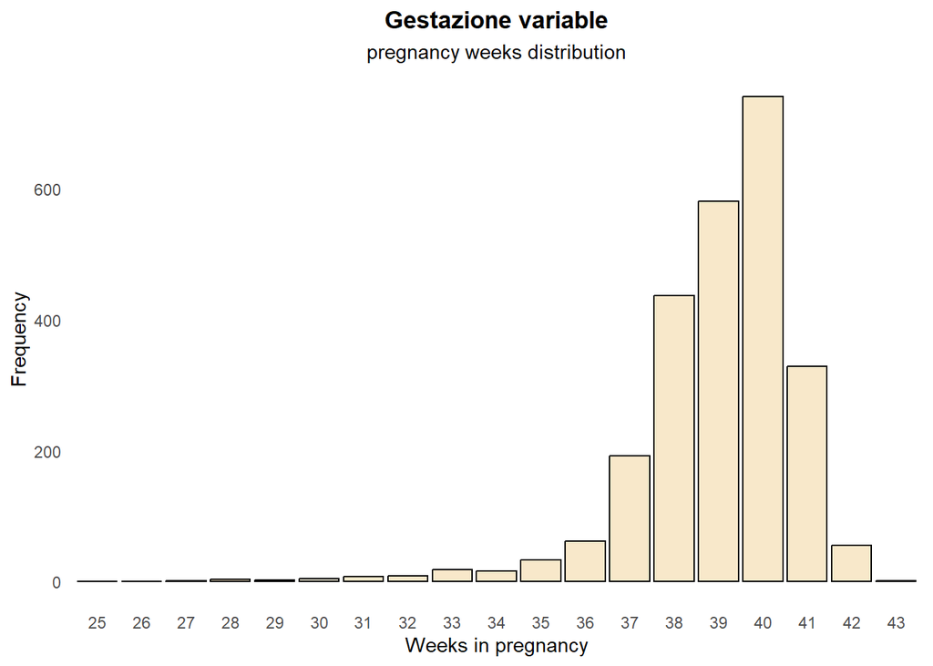

```r
ggplot() +
  geom_bar(
    aes(x = as.factor(Gestazione)),
    fill = "wheat", color = "black", alpha = 0.7
  ) +
  labs(
    x = "Weeks in pregnancy",
    y = "Frequency",
    title = "Gestazione variable",
    subtitle = "pregnancy weeks distribution"
  ) +
  theme_minimal() +
  theme(
    panel.grid = element_blank(),
    plot.title = element_text(hjust = 0.5, face = "bold"),
    plot.subtitle = element_text(hjust = 0.5)
  )
```

#### **Peso:**

```r
weight_class = cut(Peso, breaks = seq(500,5000, by=500),
                   left=FALSE,
                   labels = paste0("(", seq(500,4500, by=500), "-", seq(1000,5000, by=500), "]")
                   )
weightn_distribution = table(weight_class)
weightn_frtable = weightn_distribution/sum(weightn_distribution)
weight_cumsum = cumsum(weightn_distribution)
weight_cumrel = weight_cumsum/sum(weightn_distribution)

final_weighttable = cbind(ni=weightn_distribution, fi=weightn_frtable, Ni=weight_cumsum, Fi=weight_cumrel)
colnames(final_weighttable) = c("Absolute Fr.", "Relative Fr.", "Cumulated absolute fr.", "Cumulated relative fr.")
knitr::kable(final_weighttable)
```

|  | Absolute Fr. | Relative Fr. | Cumulated absolute fr. | Cumulated relative fr. |
| --- | --- | --- | --- | --- |
| (500-1000] | 6 | 0.0024 | 6 | 0.0024 |
| (1000-1500] | 18 | 0.0072 | 24 | 0.0096 |
| (1500-2000] | 29 | 0.0116 | 53 | 0.0212 |
| (2000-2500] | 94 | 0.0376 | 147 | 0.0588 |
| (2500-3000] | 510 | 0.2040 | 657 | 0.2628 |
| (3000-3500] | 1016 | 0.4064 | 1673 | 0.6692 |
| (3500-4000] | 662 | 0.2648 | 2335 | 0.9340 |
| (4000-4500] | 147 | 0.0588 | 2482 | 0.9928 |
| (4500-5000] | 18 | 0.0072 | 2500 | 1.0000 |

```r
summary(Peso)
```

```
##    Min. 1st Qu.  Median    Mean 3rd Qu.    Max.
##     830    2990    3300    3284    3620    4930
```

```r
weight_data = data.frame(
  Skewness = round(skewness(Peso), 2),
  Kurtosis = round(kurtosis(Peso)-3, 2),
  St_dev = round(sd(Peso), 2)
)
knitr::kable(weight_data)
```

| Skewness | Kurtosis | St_dev |
| --- | --- | --- |
| -0.65 | 2.03 | 525.04 |

For the preliminary analysis of the variable Peso, considering that, according to the guidelines from Ospedale Bambino Gesù in Rome cited above, a newborn is considered potentially preterm if it has a weight less than or equal to 2500g, we prefer to create right-closed classes to build a frequency table that highlights how observations below 2500g account for 5.8% of the total sample, warranting attention from healthcare personnel.

There is not a large difference between the mean and the median, an indication that we are unlikely to have outliers affecting the results. The negative skew indicates a tendency of the distribution toward higher values, with a leptokurtic curve.

Let’s build the distribution density curve:

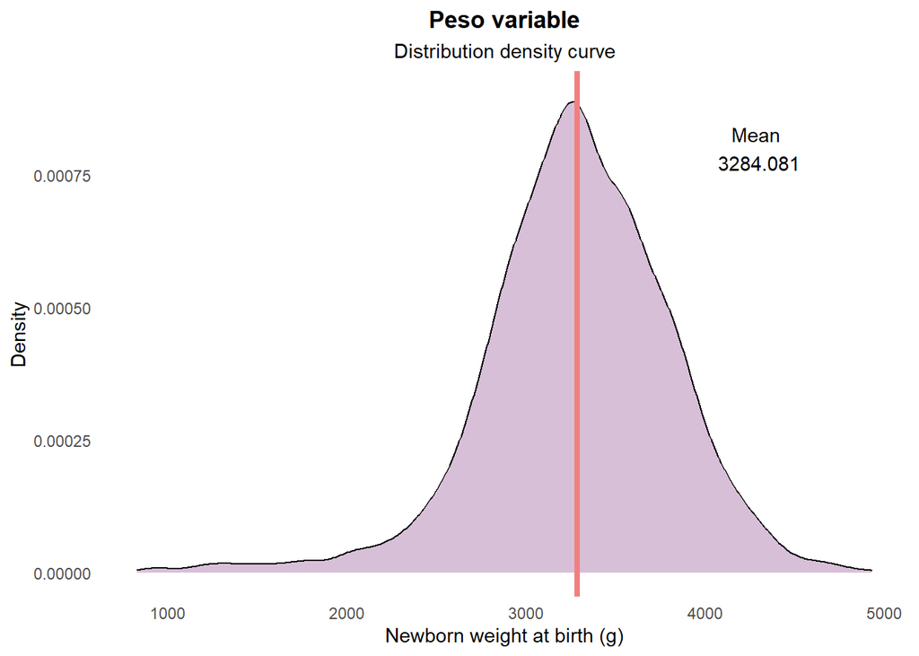

```r
ggplot()+
  geom_density(aes(x=Peso), col="black", fill="thistle")+
  geom_vline(xintercept = mean(Peso), linewidth=1.5, color = "lightcoral")+
  labs(x="Newborn weight at birth (g)", y="Density", title = "Peso variable", subtitle = "Distribution density curve")+
  geom_text(aes(x = mean(Peso) + 1000, y = 8e-04, label = sprintf("Mean\n %.3f", mean(Peso))), inherit.aes = FALSE) +
  ylim(0, 9e-04)+
  theme_minimal()+
  theme(
    panel.grid = element_blank(),
    plot.title = element_text(hjust = 0.5, face = "bold"),
    plot.subtitle = element_text(hjust = 0.5)
  )
```

The previous observations are confirmed by the plot.

Since the variable Peso will be our response variable in the regression model we will develop, we immediately perform a Shapiro test to check whether it follows a normal distribution.

```r
shapiro.test(Peso)
```

```
##
##  Shapiro-Wilk normality test
##
## data:  Peso
## W = 0.97066, p-value < 2.2e-16
```

With a p-value effectively equal to zero and a W statistic of 0.97, we must reject the null hypothesis H0 of normality. For the Shapiro test, Peso does not follow a normal distribution; however, the central limit theorem may mitigate the effect of non-normality for datasets with a large number of observations. We will evaluate the effects on the model later.

#### **Lunghezza:**

```r
length_class = cut(Lunghezza, breaks = seq(300,570, by=30),
                   left=FALSE,
                   labels = paste0("(", seq(300,540, by=30), "-", seq(330,570, by=30), "]")
                   )
lengthn_distribution = table(length_class)
lengthn_frtable = lengthn_distribution/sum(lengthn_distribution)
length_cumsum = cumsum(lengthn_distribution)
length_cumrel = length_cumsum/sum(lengthn_distribution)

final_lengthtable = cbind(ni=lengthn_distribution, fi=lengthn_frtable, Ni=length_cumsum, Fi=length_cumrel)
colnames(final_lengthtable) = c("Absolute Fr.", "Relative Fr.", "Cumulated absolute fr.", "Cumulated relative fr.")
knitr::kable(final_lengthtable)
```

|  | Absolute Fr. | Relative Fr. | Cumulated absolute fr. | Cumulated relative fr. |
| --- | --- | --- | --- | --- |
| (300-330] | 4 | 0.0016 | 4 | 0.0016 |
| (330-360] | 6 | 0.0024 | 10 | 0.0040 |
| (360-390] | 12 | 0.0048 | 22 | 0.0088 |
| (390-420] | 23 | 0.0092 | 45 | 0.0180 |
| (420-450] | 84 | 0.0336 | 129 | 0.0516 |
| (450-480] | 524 | 0.2096 | 653 | 0.2612 |
| (480-510] | 1335 | 0.5340 | 1988 | 0.7952 |
| (510-540] | 471 | 0.1884 | 2459 | 0.9836 |
| (540-570] | 41 | 0.0164 | 2500 | 1.0000 |

```r
summary(Lunghezza)
```

```
##    Min. 1st Qu.  Median    Mean 3rd Qu.    Max.
##   310.0   480.0   500.0   494.7   510.0   565.0
```

```r
length_data = data.frame(
  Skewness = round(skewness(Lunghezza), 2),
  Kurtosis = round(kurtosis(Lunghezza)-3, 2),
  St_dev = round(sd(Lunghezza), 2)
)
knitr::kable(length_data)
```

| Skewness | Kurtosis | St_dev |
| --- | --- | --- |
| -1.51 | 6.49 | 26.32 |

Most observations of the variable Lunghezza are concentrated in the 480-510 class (53.4%). [The average newborn length at birth](https://www.ospedalebambinogesu.it/da-0-a-30-giorni-come-si-presenta-e-come-cresce-80012/) is usually 500mm for males and 495mm for females according to the referenced source. Our dataset reflects this trend observed in other studies. The overall mean newborn length at birth is 494.7mm, with a median of 500mm and minimal deviation between the two measures.

We observe a negative skew with a prevalence of high values and a leptokurtic curve.

Let’s plot the density curve now.

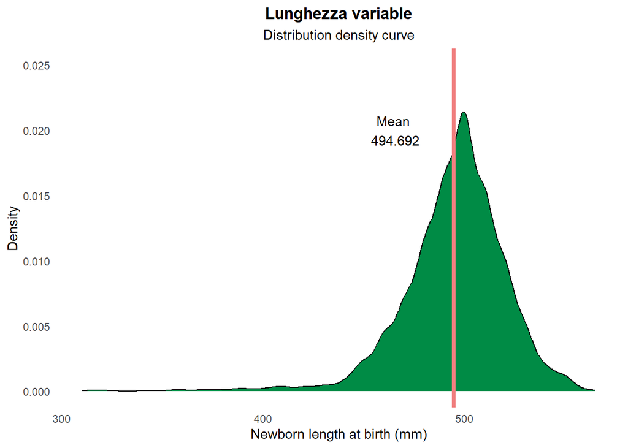

```r
ggplot()+
  geom_density(aes(x=Lunghezza), col="black", fill="springgreen4")+
  geom_vline(xintercept = mean(Lunghezza), linewidth=1.5, color = "lightcoral")+
  labs(x="Newborn length at birth (mm)", y="Density", title = "Lunghezza variable", subtitle = "Distribution density curve")+
  geom_text(aes(x = mean(Lunghezza) -30, y = 0.02, label = sprintf("Mean\n %.3f", mean(Lunghezza))), inherit.aes = FALSE) +
  ylim(0, 0.025)+
  theme_minimal()+
  theme(
    panel.grid = element_blank(),
    plot.title = element_text(hjust = 0.5, face = "bold"),
    plot.subtitle = element_text(hjust = 0.5)
  )
```

#### **Cranio:**

```r
head_class = cut(Cranio, breaks = seq(220,400, by=20),
                   left=FALSE,
                   labels = paste0("(", seq(220,380, by=20), "-", seq(240,400, by=20), "]")
)
headn_distribution = table(head_class)
headn_frtable = headn_distribution/sum(headn_distribution)
head_cumsum = cumsum(headn_distribution)
head_cumrel = head_cumsum/sum(headn_distribution)

final_headtable = cbind(ni=headn_distribution, fi=headn_frtable, Ni=head_cumsum, Fi=head_cumrel)
colnames(final_headtable) = c("Absolute Fr.", "Relative Fr.", "Cumulated absolute fr.", "Cumulated relative fr.")
knitr::kable(final_headtable)
```

|  | Absolute Fr. | Relative Fr. | Cumulated absolute fr. | Cumulated relative fr. |
| --- | --- | --- | --- | --- |
| (220-240] | 1 | 0.0004 | 1 | 0.0004 |
| (240-260] | 3 | 0.0012 | 4 | 0.0016 |
| (260-280] | 16 | 0.0064 | 20 | 0.0080 |
| (280-300] | 31 | 0.0124 | 51 | 0.0204 |
| (300-320] | 201 | 0.0804 | 252 | 0.1008 |
| (320-340] | 1057 | 0.4228 | 1309 | 0.5236 |
| (340-360] | 1006 | 0.4024 | 2315 | 0.9260 |
| (360-380] | 174 | 0.0696 | 2489 | 0.9956 |
| (380-400] | 11 | 0.0044 | 2500 | 1.0000 |

```r
summary(Cranio)
```

```
##    Min. 1st Qu.  Median    Mean 3rd Qu.    Max.
##     235     330     340     340     350     390
```

```r
head_data = data.frame(
  Skewness = round(skewness(Cranio), 2),
  Kurtosis = round(kurtosis(Cranio)-3, 2),
  St_dev = round(sd(Cranio), 2)
)
knitr::kable(head_data)
```

| Skewness | Kurtosis | St_dev |
| --- | --- | --- |
| -0.79 | 2.95 | 16.43 |

For the variable Cranio, which records the newborn’s head diameter at birth (or still in utero via ultrasound) in mm, most observations are concentrated below 360mm (93%). The minimum of 235mm and maximum of 390mm fall correctly within the class division.

Median and mean coincide at 340mm. The curve has a negative skew with predominantly high values, and a positive kurtosis of 2.95 indicating a leptokurtic curve.

Let’s build the desntiy plot for the distribution.

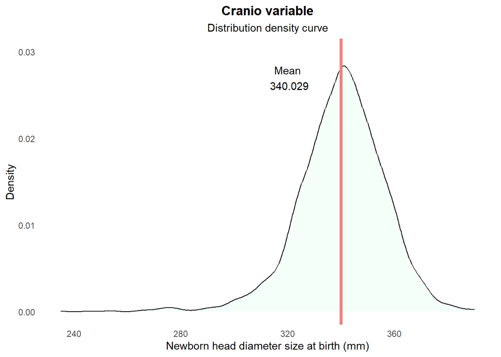

```r
ggplot()+
  geom_density(aes(x=Cranio), col="black", fill="mintcream")+
  geom_vline(xintercept = mean(Cranio), linewidth=1.5, color = "lightcoral")+
  labs(x="Newborn head diameter size at birth (mm)", y="Density", title = "Cranio variable", subtitle = "Distribution density curve")+
  geom_text(aes(x = mean(Cranio) -20, y = 0.027, label = sprintf("Mean\n %.3f", mean(Cranio))), inherit.aes = FALSE) +
  ylim(0, 0.03)+
  theme_minimal()+
  theme(
    panel.grid = element_blank(),
    plot.title = element_text(hjust = 0.5, face = "bold"),
    plot.subtitle = element_text(hjust = 0.5)
  )
```

#### **Tipo.parto:**

```r
birth_type = table(Tipo.parto)
knitr::kable(birth_type)
```

| Tipo.parto | Freq |
| --- | --- |
| Ces | 728 |
| Nat | 1772 |

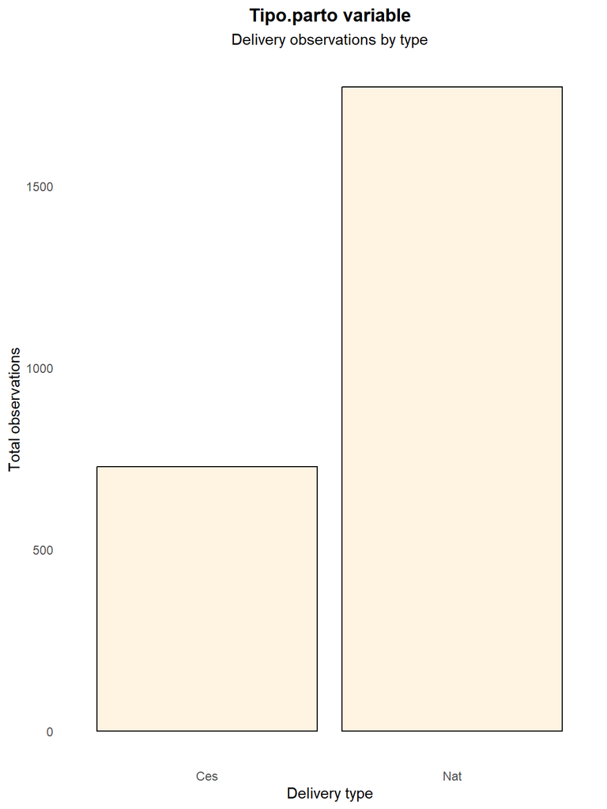

```r
ggplot() +
  geom_bar(
    aes(x = as.factor(Tipo.parto)),
    fill = "papayawhip", color = "black", alpha = 0.7
  ) +
  labs(
    x = "Delivery type",
    y = "Total observations",
    title = "Tipo.parto variable",
    subtitle = "Delivery observations by type"
  ) +
  theme_minimal() +
  theme(
    panel.grid = element_blank(),
    plot.title = element_text(hjust = 0.5, face = "bold"),
    plot.subtitle = element_text(hjust = 0.5)
  )
```

```r
birthtypeperc = round((728*100)/2500, 2)
knitr::kable(birthtypeperc)
```

| x |
| --- |
| 29.12 |

From the data observed in the three hospitals, we confirm that 29.12% of births occur by cesarean section, while the remainder are vaginal deliveries.

#### **Ospedale:**

```r
hospital = table(Ospedale)
knitr::kable(hospital)
```

| Ospedale | Freq |
| --- | --- |
| osp1 | 816 |
| osp2 | 849 |
| osp3 | 835 |

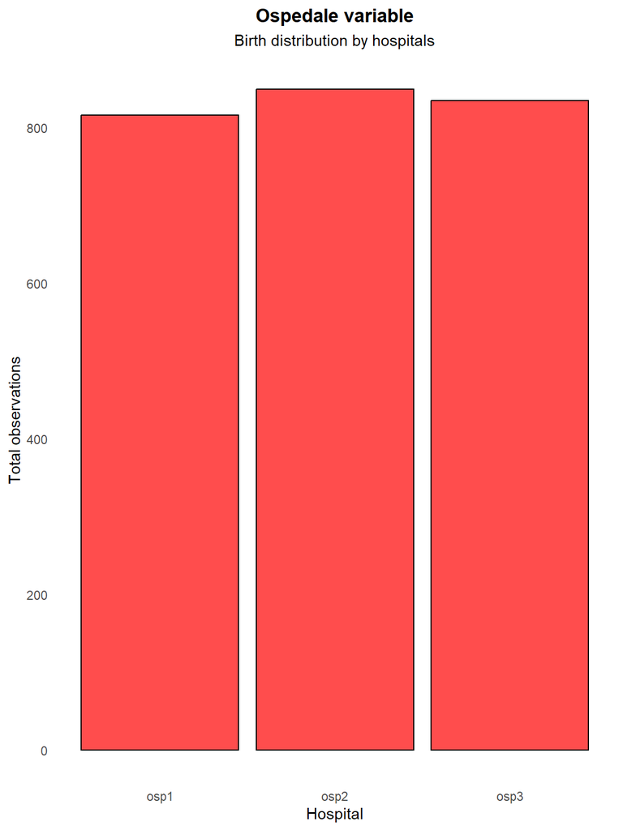

```r
ggplot() +
  geom_bar(
    aes(x = as.factor(Ospedale)),
    fill = "red", color = "black", alpha = 0.7
  ) +
  labs(
    x = "Hospital",
    y = "Total observations",
    title = "Ospedale variable",
    subtitle = "Birth distribution by hospitals"
  ) +
  theme_minimal() +
  theme(
    panel.grid = element_blank(),
    plot.title = element_text(hjust = 0.5, face = "bold"),
    plot.subtitle = element_text(hjust = 0.5)
  )
```

The variable Ospedali shows a very similiar number of observations for all three facilities, with no significant variation in the count of observations for each facility individually.

#### **Sesso:**

```r
gender = table(Sesso)
knitr::kable(gender)
```

| Sesso | Freq |
| --- | --- |
| F | 1256 |
| M | 1244 |

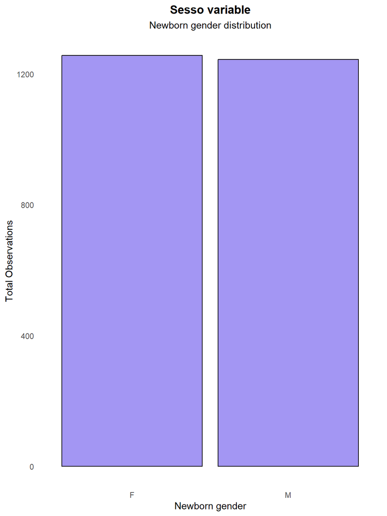

```r
ggplot() +
  geom_bar(
    aes(x = as.factor(Sesso)),
    fill = "mediumslateblue", color = "black", alpha = 0.7
  ) +
  labs(
    x = "Newborn gender",
    y = "Total Observations",
    title = "Sesso variable",
    subtitle = "Newborn gender distribution"
  ) +
  theme_minimal() +
  theme(
    panel.grid = element_blank(),
    plot.title = element_text(hjust = 0.5, face = "bold"),
    plot.subtitle = element_text(hjust = 0.5)
  )
```

No significant differences are observed between male and gemale births in the sample of 2500 newborns.

## **Analysis of relationships between variables and newborn weight**

#### **Genere sessuale and Peso relation:**

Before evaluating relations between maternal variables and newborn weight, it is first worthwhile to check whether there is a natural weight difference between male and female newborns. We’ll build the chart below.

```r
library(dplyr)
male_stats = neonatalcare_data %>%
  filter(Sesso == "M") %>%
  summarise(
    Mean = mean(Peso, na.rm = TRUE),
    Median = median(Peso, na.rm = TRUE),
    St_dev = sd(Peso, na.rm = TRUE),
    Minimum = min(Peso, na.rm = TRUE),
    Maximum = max(Peso, na.rm = TRUE),
    Quartile1 = quantile(Peso, 0.25, na.rm = TRUE),
    Quartile3 = quantile(Peso, 0.75, na.rm = TRUE)
  )

female_stats = neonatalcare_data %>%
  filter(Sesso == "F") %>%
  summarise(
    Mean = mean(Peso, na.rm = TRUE),
    Median = median(Peso, na.rm = TRUE),
    St_dev = sd(Peso, na.rm = TRUE),
    Minimum = min(Peso, na.rm = TRUE),
    Maximum = max(Peso, na.rm = TRUE),
    Quartile1 = quantile(Peso, 0.25, na.rm = TRUE),
    Quartile3 = quantile(Peso, 0.75, na.rm = TRUE)
  )

gender_weight_table = rbind(
  Males = male_stats,
  Females = female_stats
)

knitr::kable(gender_weight_table)
```

|  | Mean | Median | St_dev | Minimum | Maximum | Quartile1 | Quartile3 |
| --- | --- | --- | --- | --- | --- | --- | --- |
| Males | 3408.215 | 3430 | 493.8043 | 980 | 4810 | 3150 | 3720 |
| Females | 3161.132 | 3160 | 526.3091 | 830 | 4930 | 2900 | 3470 |

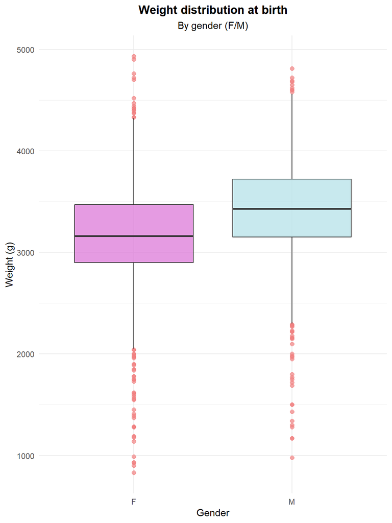

```r
ggplot(neonatalcare_data, aes(x = Sesso, y = Peso, fill = Sesso))+
  geom_boxplot(outlier.colour = "lightcoral", outlier.size = 2, alpha = 0.7)+
  labs(
    title = "Weight distribution at birth",
    subtitle = "By gender (F/M)",
    x = "Gender",
    y = "Weight (g)"
  )+
  scale_fill_manual(values = c("M" = "powderblue", "F" = "orchid"))+
  theme_minimal()+
  theme(
    plot.title = element_text(hjust = 0.5, face = "bold"),
    plot.subtitle = element_text(hjust = 0.5),
    legend.position = "none"
  )
```

Both the boxplots and the variability and central tendency indices for the weight distribution split by sex provide strong evidence that male newborns’ birth weight is significantly different from female newborns’.

To verify that the difference is statistically significant, we set the null hypothesis **“H0 = the mean weights of male and female newborns are equal”** and perform a Student’s t-test below.

```r
t.test(Peso ~ Sesso, data = neonatalcare_data)
```

```
##
##  Welch Two Sample t-test
##
## data:  Peso by Sesso
## t = -12.106, df = 2490.7, p-value < 2.2e-16
## alternative hypothesis: true difference in means between group F and group M is not equal to 0
## 95 percent confidence interval:
##  -287.1051 -207.0615
## sample estimates:
## mean in group F mean in group M
##        3161.132        3408.215
```

The test returns a p-value effectively equal to 0, indicating that the mean weight difference between male and female newborns is statistically significant, and therefore leads us to reject the null hypothesis H0 stated above.

Is also indicates that, in our dataset, the mean weight of female newborns is lower than that of males by an amount ranging from 207.06 to 287.11 g at birth.

#### **Ospedali and Peso relation:**

Before considering maternal variables in relation to weight, it is also worth checking whether there are substantial differences in newborn weight across three hospitals separately.

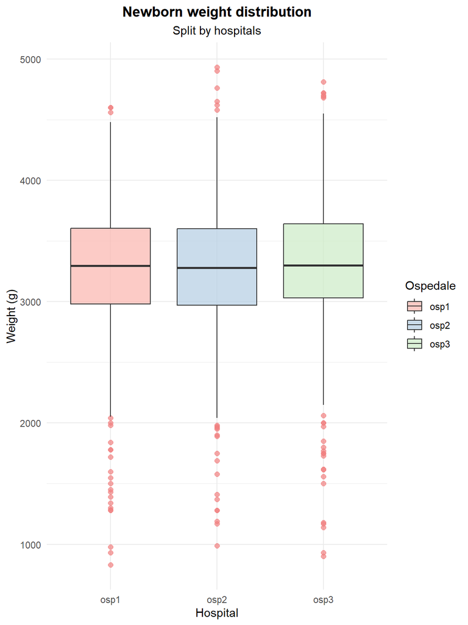

```r
ggplot(neonatalcare_data, aes(x = Ospedale, y = Peso, fill = Ospedale))+
  geom_boxplot(outlier.colour = "lightcoral", outlier.size = 2, alpha = 0.7)+
  labs(
    title = "Newborn weight distribution",
    subtitle = "Split by hospitals",
    x = "Hospital",
    y = "Weight (g)"
  )+
  scale_fill_brewer(palette = "Pastel1")+
  theme_minimal()+
  theme(
    plot.title = element_text(hjust=0.5, face = "bold"),
    plot.subtitle = element_text(hjust = 0.5),
  )
```

Graphical examination does not show significant differences in the weight distribution across the three hospitals in the dataset.

#### **Newborn weight and delivery type relation:**

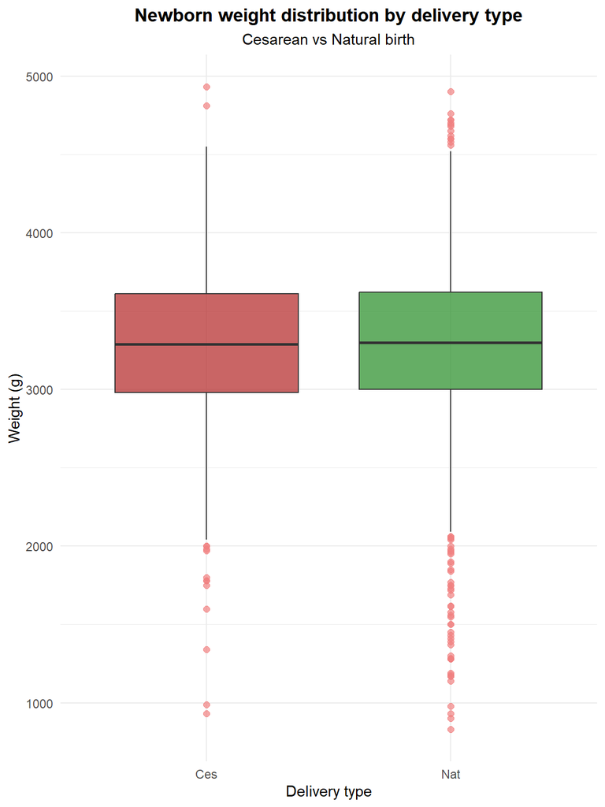

```r
ggplot(neonatalcare_data, aes(x = Tipo.parto, y = Peso, fill = Tipo.parto))+
  geom_boxplot(outlier.colour = "lightcoral", outlier.size = 2, alpha = 0.7)+
  labs(
    title = "Newborn weight distribution by delivery type",
    subtitle = "Cesarean vs Natural birth",
    x = "Delivery type",
    y = "Weight (g)"
  )+
  scale_fill_manual(values = c("Nat" = "forestgreen", "Ces" = "firebrick"))+
  theme_minimal()+
  theme(
    plot.title = element_text(hjust = 0.5, face = "bold"),
    plot.subtitle = element_text(hjust = 0.5),
    legend.position = "none"
  )
```

We observe graphically that there is no influence on the newborn weight distribution indices even when discriminating by delivery type.

#### **Relation between newborn weight, delivery type and hospital:**

We can further detail the analysis of the relation between variables by also checking whether, within each hospital, there are differences between vaginal and cesarean deliveries.

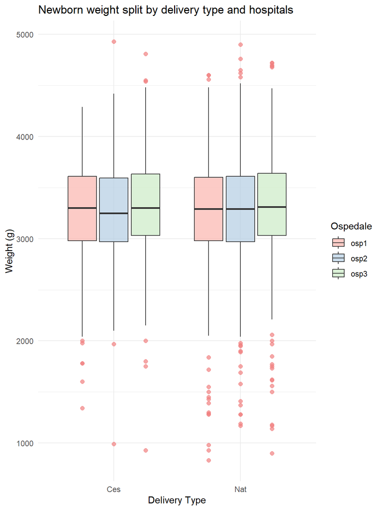

```r
ggplot(data = neonatalcare_data, aes(x = Tipo.parto, y = Peso, fill = Ospedale)) +
  geom_boxplot(outlier.colour = "lightcoral", outlier.size = 2, alpha = 0.7) +
  labs(title = "Newborn weight split by delivery type and hospitals",
       x = "Delivery Type",
       y = "Weight (g)") +
  scale_fill_brewer(palette = "Pastel1")+
  theme_minimal()
```

At first glance there appear to be fluctuations among the distributions of cesarean births when split by hospital, so we will proceed to perform a two-way ANOVA with the following null hypotheses H0:

- For “Tipo di Parto”: there are no significant differences in mean newborn weights between cesarean and vaginal deliveries;
- For “Ospedale”: there are no significant differences in mean newborn weights among the three hospitals;
- For “Interazione”: there is no significant interaction between delivery type and hospital;

This test will help to statistically verify what was observed in the two previous charts.

```r
anov_result = aov(Peso ~ Tipo.parto * Ospedale, data = neonatalcare_data)
summary(anov_result)
```

```
##                       Df    Sum Sq Mean Sq F value Pr(>F)
## Tipo.parto             1      4250    4250   0.015  0.901
## Ospedale               2    934018  467009   1.693  0.184
## Tipo.parto:Ospedale    2     82304   41152   0.149  0.861
## Residuals           2494 687867970  275809
```

As shown by the p-values, we fail to reject the null hypothesis H0 for this test, since for all three hypotheses the test indicates that there are no statistically significant differences either within groups or between groups.

#### **Mother’s age and newborn weight relation:**

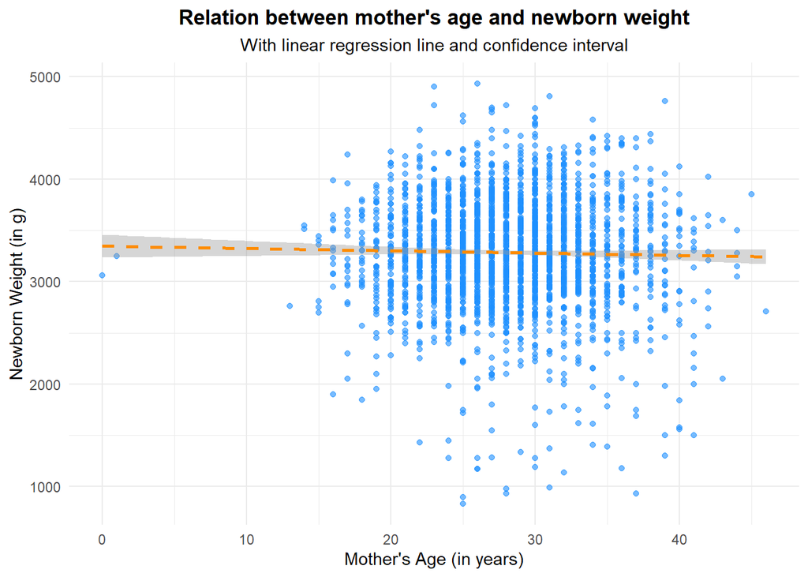

```r
ggplot(neonatalcare_data, aes(x = Anni.madre, y = Peso))+
  geom_point(alpha = 0.6, color = "dodgerblue")+
  geom_smooth(method = "lm", color = "darkorange", se = TRUE, linetype = "dashed")+
  labs(
    title = "Relation between mother's age and newborn weight",
    x = "Mother's Age (in years)",
    y = "Newborn Weight (in g)",
    subtitle = "With linear regression line and confidence interval"
  )+
  theme_minimal()+
  theme(
    plot.title = element_text(hjust = 0.5, face = "bold"),
    plot.subtitle = element_text(hjust = 0.5)
  )
```

Plotting mother’s age against newborn birth weight shows a concentration of values between 2500g and 4000g, as previously observed in the frequency table for Peso. Outlier values for mothers aged 0 and 1 are also noted in the dedicated section.

There does not appear to be any significant relationship between the two variables, and the nearly horizontal regression line with its shown confidence interval confirms this.

#### **Newborn weight and pregnancy number relation:**

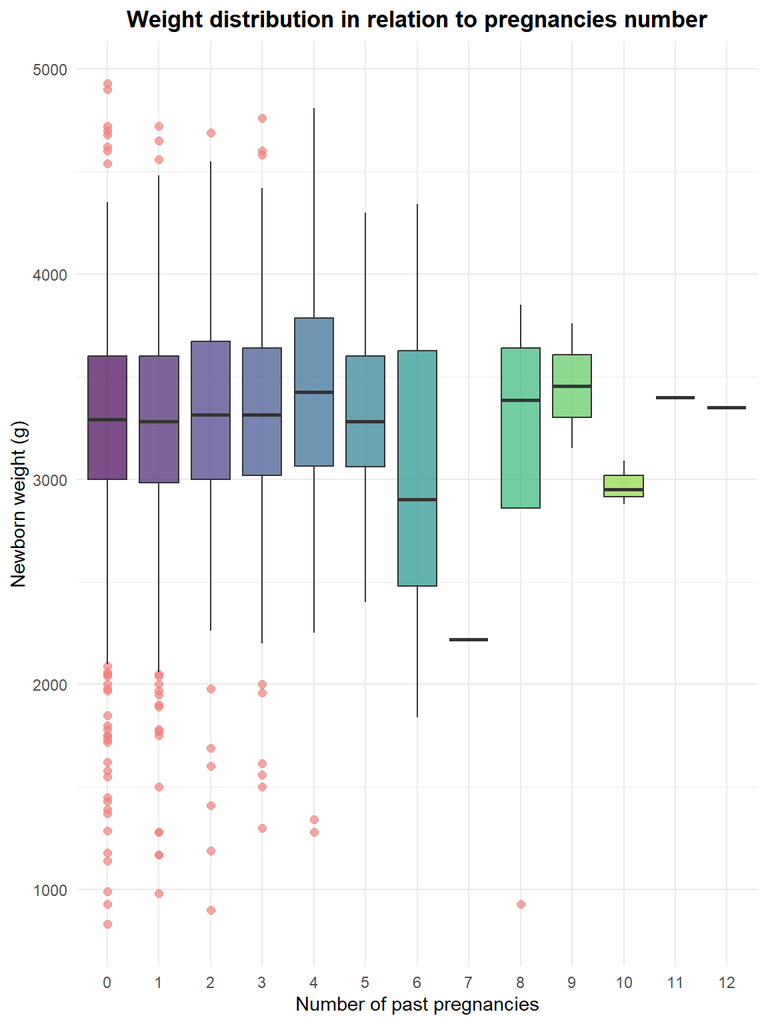

```r
ggplot(neonatalcare_data, aes(x = factor(N.gravidanze), y = Peso, fill = factor(N.gravidanze))) +
  geom_boxplot(outlier.colour = "lightcoral", outlier.size = 2, alpha = 0.7) +
  labs(
    title = "Weight distribution in relation to pregnancies number",
    x = "Number of past pregnancies",
    y = "Newborn weight (g)"
  ) +
  scale_fill_viridis_d() +
  theme_minimal() +
  theme(
    plot.title = element_text(hjust = 0.5, face = "bold"),
    legend.position = "none"
  )
```

Using the boxplot above we relate newborn birth weight to the total number of pregnancies the mother has had in her medical history. We immediately note a large number of outliers up to 3 pregnancies, likely attributable to difficult or anomalous pregnancies.

We also observe no substantial differences in weight indices up to subjects with 6 total pregnancies, where the min/max shift and the interquartile range is much extended compared to other pregnancy count conditions. The same applies to individuals with 8,9 or 10 total pregnancies, which show markedly different indices compared to the initial conditions 0,1,2,3.

We hypothesize however that since pregnancies greater than 2 become progressively less common up to 12, we do not have sufficient data in this area of the dataset to reliably verify the weight/number of pregnancies relations above 5 total pregnancies.

We can further split the boxplot by male and female newborns to see whether the observed relationship trend between the variables holds when discriminating by sex.

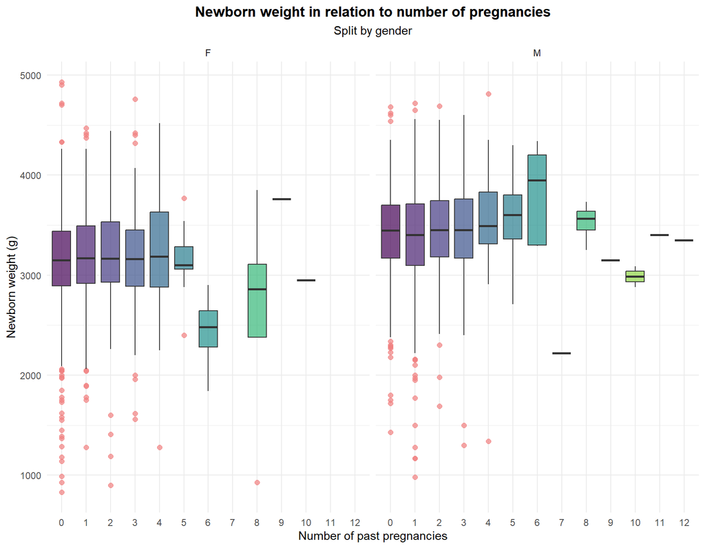

```r
ggplot(neonatalcare_data, aes(x = factor(N.gravidanze), y = Peso, fill = factor(N.gravidanze))) +
  geom_boxplot(outlier.colour = "lightcoral", outlier.size = 2, alpha = 0.7) +
  labs(
    title = "Newborn weight in relation to number of pregnancies",
    subtitle = "Split by gender",
    x = "Number of past pregnancies",
    y = "Newborn weight (g)"
  ) +
  facet_wrap(~ Sesso) +
  scale_fill_viridis_d() +
  theme_minimal() +
  theme(
    plot.title = element_text(hjust = 0.5, face = "bold"),
    plot.subtitle = element_text(hjust = 0.5),
    legend.position = "none"
  )
```

When we split the boxplot by female and male newborns, we observe that births from mothers with 5 total pregnancies also appear to show visually significant differences in the distribution indices; moreover, for males the boxplot for mothers with 9 total pregnancies loses significance, again supporting the idea that above five pregnancies we may not have sufficient observations.

We also note that for mothers with 6 total pregnancies, males show a median line substantially higher than the others, while for females the median is around the 2,500 gram line, which could be problematic because it is indicative of a potentially premature newborn.

In this case, we recommend enlarging the sample in future data collection to verify that the trends observed in the relationship between weight and number of pregnancies for mothers with more than five pregnancies are confirmed.

#### **Tobacco usage habits and newborn weight relations:**

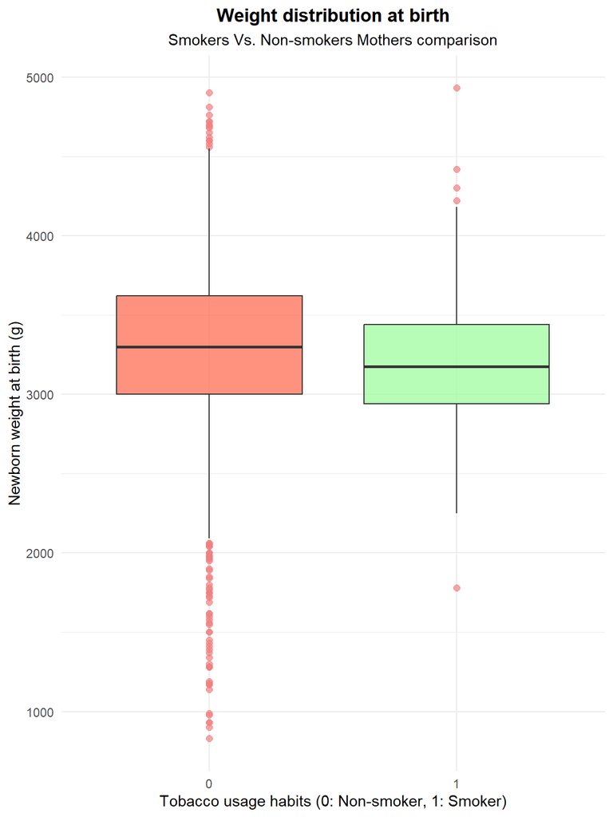

```r
ggplot(neonatalcare_data, aes(x= as.factor(Fumatrici), y = Peso, fill = as.factor(Fumatrici)))+
  geom_boxplot(outlier.colour = "lightcoral", outlier.size = 2, alpha = 0.7)+
  labs(
    title = "Weight distribution at birth",
    subtitle = "Smokers Vs. Non-smokers Mothers comparison",
    x = "Tobacco usage habits (0: Non-smoker, 1: Smoker)",
    y = "Newborn weight at birth (g)"
  )+
  scale_fill_manual(values = c("0"="tomato", "1" = "palegreen"),
                    labels = c("Non-smokers", "Smokers"))+
  theme_minimal()+
  theme(
    plot.title = element_text(hjust = 0.5, face = "bold"),
    plot.subtitle = element_text(hjust = 0.5),
    legend.position = "none"
  )
```

We made a boxplot to compare the relations between maternal smoking habits and newborn weight. At first glance there appears to be a relationship as the median of the distribution for smoking mothers is slightly lower than that for non-smoking mothers.

Note that the sample includes only 4.16% smoking mothers of the total n samples, so the data may be insufficient to reveal a clear trend.

We nevertheless decide to perform a t-test with null hypothesis H0: “There is no difference between the mean weights of both groups” to verify whether the variations observed in the plot are statistically significant.

```r
t.test(Peso ~ Fumatrici, data = neonatalcare_data)
```

```
##
##  Welch Two Sample t-test
##
## data:  Peso by Fumatrici
## t = 1.034, df = 114.1, p-value = 0.3033
## alternative hypothesis: true difference in means between group 0 and group 1 is not equal to 0
## 95 percent confidence interval:
##  -45.61354 145.22674
## sample estimates:
## mean in group 0 mean in group 1
##        3286.153        3236.346
```

Having a p-value greater than 0.05 and a difference between means of only 50 grams, we consider that the difference in weight between infants born to smoking and non-smoking mothers is, on average, not statistically significant, nor likely to have a strong relation with neonatal birth weight. We therefore require a more in-depth analysis of the factors influencing neonatal birth weight. Let us proceed.

#### **Gestation weeks, length, head circumference and weight relations:**

Having investigated the relations between weight and gender, we can now proceed to examine the relations between weeks of gestation, length, head circumference and weight, in which we hypothesize an almost obvious linear correlation. We’ll display the charts below.

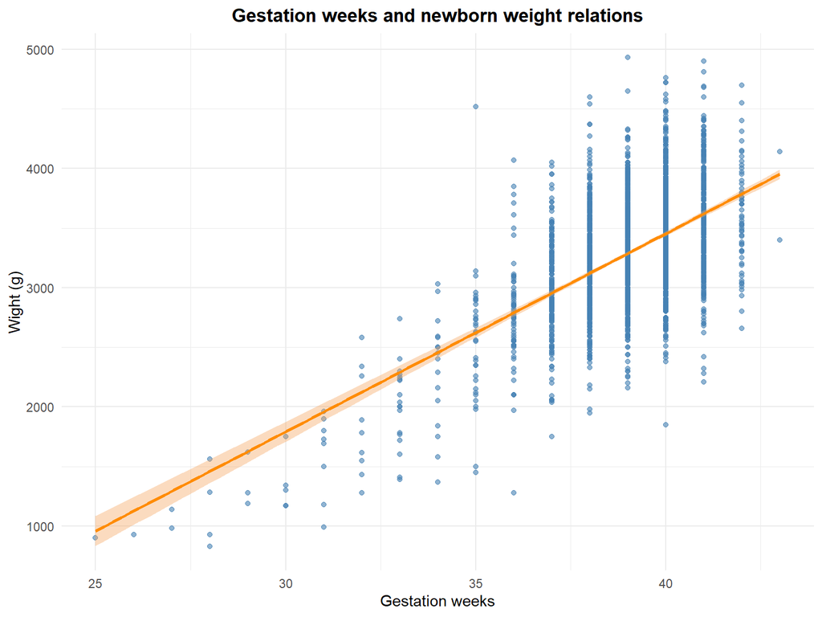

```r
ggplot(neonatalcare_data, aes(x= Gestazione, y = Peso))+
  geom_point(alpha = 0.6, color = "steelblue")+
  geom_smooth(method = "lm", se = TRUE, color = "darkorange", fill = "sandybrown")+
  labs(
    title = "Gestation weeks and newborn weight relations",
    x = "Gestation weeks",
    y = "Wight (g)"
  )+
  theme_minimal()+
  theme(
    plot.title = element_text(hjust = 0.5, face = "bold")
  )
```

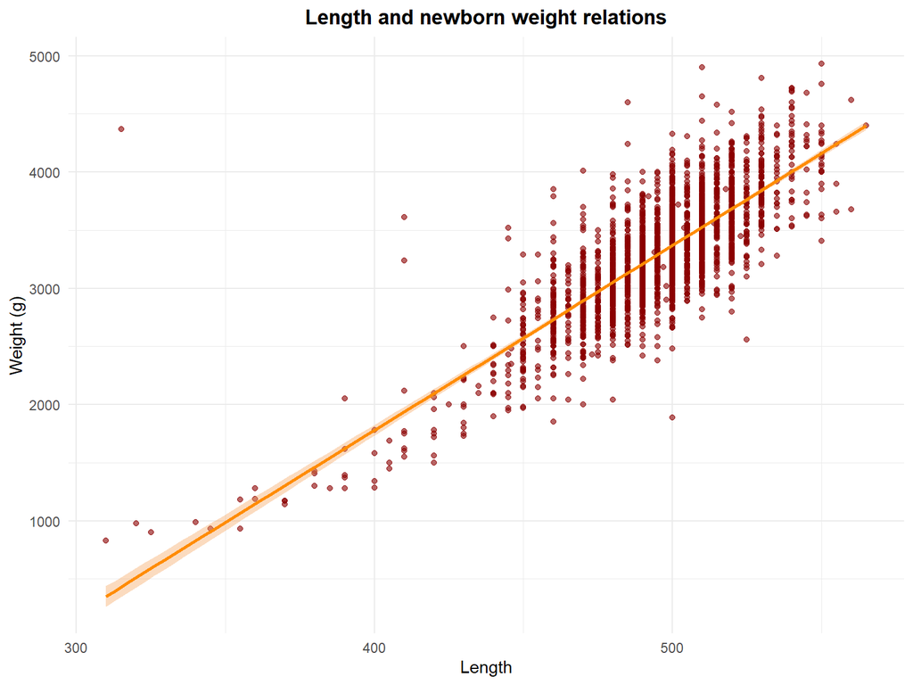

```r
ggplot(neonatalcare_data, aes(x= Lunghezza, y = Peso))+
  geom_point(alpha = 0.6, color = "darkred")+
  geom_smooth(method = "lm", se = TRUE, color = "darkorange", fill = "sandybrown")+
  labs(
    title = "Length and newborn weight relations",
    x = "Length",
    y = "Weight (g)"
  )+
  theme_minimal()+
  theme(
    plot.title = element_text(hjust = 0.5, face = "bold")
  )
```

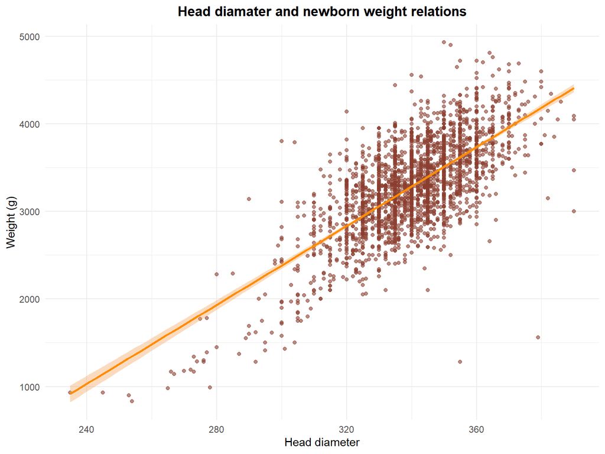

```r
ggplot(neonatalcare_data, aes(x= Cranio, y = Peso))+
  geom_point(alpha = 0.6, color = "coral4")+
  geom_smooth(method = "lm", se = TRUE, color = "darkorange", fill = "sandybrown")+
  labs(
    title = "Head diamater and newborn weight relations",
    x = "Head diameter",
    y = "Weight (g)"
  )+
  theme_minimal()+
  theme(
    plot.title = element_text(hjust = 0.5, face = "bold")
  )
```

We identify a strong positive linear correlation between neonatal weight and gestation weeks. The same holds for weight with head circumference and length: as these three variables increase, neonatal weight also increases on average.

## **Building of a multiple linear regression model and optimal model selection.**

Having established that not all dataset variables have a strong linear relationship with neonatal weight, and that the variables may affect it differently, we build a multiple linear regression model to understand how all variables act on neonatal weight and which are not relevant for our statistical investigation specifically.

We will first build a correlation matrix to perform a preliminary analysis of the correlations among variables and obtain a summary.

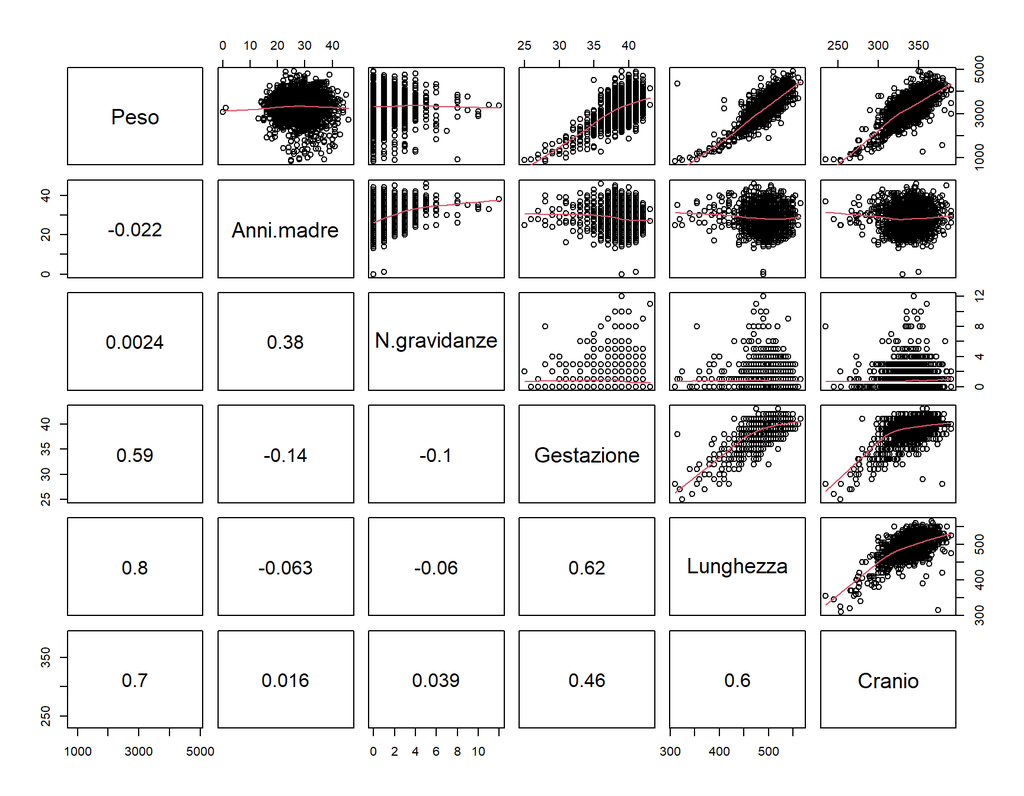

```r
library(dplyr)

panel.cor = function(x, y, digits = 2, prefix = "", cex.cor, ...)
{
  usr = par("usr"); on.exit(par(usr))
  par(usr = c(0, 1, 0, 1))
  r = (cor(x, y))
  txt = format(c(r, 1), digits = digits)[1]
  txt = paste0(prefix, txt)
  if(missing(cex.cor)) cex.cor = 0.8/strwidth(txt)
  text(0.5, 0.5, txt, cex = 1.5)
}

data_select = neonatalcare_data %>%
  select(Peso, Anni.madre, N.gravidanze, Gestazione, Lunghezza, Cranio)

pairs(data_select, lower.panel=panel.cor, upper.panel = panel.smooth)
```

From the correlation matrix we immediately note that Gestation and Weight have a correlation factor of 0.6, as previously observed, so the gestation variable has an influence on neonatal weight worth exploring.

As weight increases with advancing through gestation weeks, we hypothesize that fetal/infant dimensions in terms of length also increase, which is why we observe a correlation between Gestation, Length and head diameter that translates into correlations of 0.8 and 0.7 with Weight respectively.

The scatterplots show that all three variables positively influence Weight, so they should be included in our model. We do not observe a significant correlation of other variables with Weight.

Given the above considerations, and the earlier ones from the relations analysis, we will take everything into account when building our model.

#### **Building an initial test model using all variables:**

We develop the first version of our multiple linear regression model below by including all quantitative variables from the dataset, and examine the results so we can improve it further. We will use the stepwise procedure, performing a general analysis and then removing variables one by one to arrive at a parsimonious model with the highest possible predictive power overall.

```r
model_1 = lm(Peso ~ Anni.madre + N.gravidanze +  Fumatrici + Gestazione + Lunghezza + Cranio + Sesso, data = neonatalcare_data)
summary(model_1)
```

```
##
## Call:
## lm(formula = Peso ~ Anni.madre + N.gravidanze + Fumatrici + Gestazione +
##     Lunghezza + Cranio + Sesso, data = neonatalcare_data)
##
## Residuals:
##      Min       1Q   Median       3Q      Max
## -1161.56  -181.19   -15.75   163.70  2630.75
##
## Coefficients:
##                Estimate Std. Error t value Pr(>|t|)
## (Intercept)  -6714.4109   141.1515 -47.569  < 2e-16 ***
## Anni.madre       0.9585     1.1347   0.845   0.3984
## N.gravidanze    11.2756     4.6690   2.415   0.0158 *
## Fumatrici      -30.2959    27.5971  -1.098   0.2724
## Gestazione      32.9331     3.8267   8.606  < 2e-16 ***
## Lunghezza       10.2342     0.3009  34.009  < 2e-16 ***
## Cranio          10.5177     0.4268  24.642  < 2e-16 ***
## SessoM          78.0845    11.2039   6.969 4.06e-12 ***
## ---
## Signif. codes:  0 '***' 0.001 '**' 0.01 '*' 0.05 '.' 0.1 ' ' 1
##
## Residual standard error: 274.6 on 2492 degrees of freedom
## Multiple R-squared:  0.7272, Adjusted R-squared:  0.7264
## F-statistic:   949 on 7 and 2492 DF,  p-value: < 2.2e-16
```

Let’s start by the most important results. The value of our adjusted coefficient of determination (adjusted R-squared) is 0.7264, indicating that the model built this way can already be considered a good one, since it explains 72.64% of variability alone in newborn weight.

With such a small p-value we know the model is highly significant in general.

Of all the variables considered, Anni.madre and Fumatrici do not significantly influence the response, exceeding 0.05 with a much higher p-value. In the next test models we will remove these two variables one at a time and observe the effects on the model to understand how it responds.

The number of pregnancies, however, with 0.0158 is statistically significant, since an increase in the number of pregnancies is associated, on average, with a increase of 11.28g in newborn weight for each prior pregnancy.

Let’s remove the Anni.madre variable from the model and observe the results.

```r
model_2 = update(model_1,~. -Anni.madre)
summary(model_2)
```

```
##
## Call:
## lm(formula = Peso ~ N.gravidanze + Fumatrici + Gestazione + Lunghezza +
##     Cranio + Sesso, data = neonatalcare_data)
##
## Residuals:
##     Min      1Q  Median      3Q     Max
## -1150.3  -181.3   -15.7   163.0  2636.3
##
## Coefficients:
##                Estimate Std. Error t value Pr(>|t|)
## (Intercept)  -6681.6714   135.7178 -49.232  < 2e-16 ***
## N.gravidanze    12.7185     4.3450   2.927  0.00345 **
## Fumatrici      -30.4634    27.5948  -1.104  0.26972
## Gestazione      32.5914     3.8051   8.565  < 2e-16 ***
## Lunghezza       10.2341     0.3009  34.011  < 2e-16 ***
## Cranio          10.5359     0.4262  24.718  < 2e-16 ***
## SessoM          78.1713    11.2028   6.978 3.83e-12 ***
## ---
## Signif. codes:  0 '***' 0.001 '**' 0.01 '*' 0.05 '.' 0.1 ' ' 1
##
## Residual standard error: 274.6 on 2493 degrees of freedom
## Multiple R-squared:  0.7271, Adjusted R-squared:  0.7265
## F-statistic:  1107 on 6 and 2493 DF,  p-value: < 2.2e-16
```

In the second test, the N.gravidanze variable has a lower p-value than in the first test, gaining greater significance and changing the average effect from 11.28 to 12.71 per prior pregnancy. The adjusted coefficient of determination slightly improved (0.7265), indicating an efficient and more parsimonious model

Let’s proceed to also remove the Fumatrici variable.

```r
model_3 = update(model_2, ~. -Fumatrici)
summary(model_3)
```

```
##
## Call:
## lm(formula = Peso ~ N.gravidanze + Gestazione + Lunghezza + Cranio +
##     Sesso, data = neonatalcare_data)
##
## Residuals:
##      Min       1Q   Median       3Q      Max
## -1149.44  -180.81   -15.58   163.64  2639.72
##
## Coefficients:
##                Estimate Std. Error t value Pr(>|t|)
## (Intercept)  -6681.1445   135.7229 -49.226  < 2e-16 ***
## N.gravidanze    12.4750     4.3396   2.875  0.00408 **
## Gestazione      32.3321     3.7980   8.513  < 2e-16 ***
## Lunghezza       10.2486     0.3006  34.090  < 2e-16 ***
## Cranio          10.5402     0.4262  24.728  < 2e-16 ***
## SessoM          77.9927    11.2021   6.962 4.26e-12 ***
## ---
## Signif. codes:  0 '***' 0.001 '**' 0.01 '*' 0.05 '.' 0.1 ' ' 1
##
## Residual standard error: 274.6 on 2494 degrees of freedom
## Multiple R-squared:  0.727,  Adjusted R-squared:  0.7265
## F-statistic:  1328 on 5 and 2494 DF,  p-value: < 2.2e-16
```

The third test model removes the Fumatrici variable and confirms an adjusted percentage of 72.65% in explaining the variability of newborn weight.

N.gravidanze experienced a slight increase in p-value but, considering that the residuals are still 274.6, that R-squared is unchanged, and that we have an optimal p-value overall, this is a change that makes model 3 simpler and with predictive performance even slightly improved compare to the other two.

Let’s now proceed to evaluate what happens if we remove N.gravidanze itself, which, among the statistically relevant variables considered has the highest p-value of all and the smallest impact in terms of influence on the response.

```r
model_4 = update(model_3, ~. -N.gravidanze)
summary(model_4)
```

```
##
## Call:
## lm(formula = Peso ~ Gestazione + Lunghezza + Cranio + Sesso,
##     data = neonatalcare_data)
##
## Residuals:
##     Min      1Q  Median      3Q     Max
## -1138.2  -184.3   -17.6   163.3  2627.3
##
## Coefficients:
##               Estimate Std. Error t value Pr(>|t|)
## (Intercept) -6651.1188   135.5172 -49.080  < 2e-16 ***
## Gestazione     31.2737     3.7856   8.261 2.31e-16 ***
## Lunghezza      10.2054     0.3007  33.939  < 2e-16 ***
## Cranio         10.6704     0.4245  25.139  < 2e-16 ***
## SessoM         79.1049    11.2117   7.056 2.22e-12 ***
## ---
## Signif. codes:  0 '***' 0.001 '**' 0.01 '*' 0.05 '.' 0.1 ' ' 1
##
## Residual standard error: 275 on 2495 degrees of freedom
## Multiple R-squared:  0.7261, Adjusted R-squared:  0.7257
## F-statistic:  1654 on 4 and 2495 DF,  p-value: < 2.2e-16
```

Removing N.gravidanze did not undermine the models’ predictive quality for newborn weight. We note the adjusted coefficient of determination decreased slightly, but not in a statistically meaningful way, from 72.65% to 72.57%, keeping the proportion of explained variability nearly intact.

Our p-value is still effectively zero and the residual spread did not change in a concerning way, moving from 274.6 to 275.

The F-statistic, which communicates the overall quality of the model increased to 1654, leading us to consider the current version the simplest and a good candidate for a final model alongside model 3.

For completeness and correctness in implementing the stepwise procedure, we will nevertheless list below the remaining attempts in which we will examine what happens if we remove one or more statistically relevant variables from the model.

```r
model_5 = update(model_4, ~. -Sesso)
summary(model_5)
```

```
##
## Call:
## lm(formula = Peso ~ Gestazione + Lunghezza + Cranio, data = neonatalcare_data)
##
## Residuals:
##      Min       1Q   Median       3Q      Max
## -1105.77  -183.25   -12.83   166.41  2623.80
##
## Coefficients:
##               Estimate Std. Error t value Pr(>|t|)
## (Intercept) -6777.1203   135.6417 -49.963   <2e-16 ***
## Gestazione     31.6901     3.8219   8.292   <2e-16 ***
## Lunghezza      10.4252     0.3020  34.522   <2e-16 ***
## Cranio         10.7892     0.4282  25.194   <2e-16 ***
## ---
## Signif. codes:  0 '***' 0.001 '**' 0.01 '*' 0.05 '.' 0.1 ' ' 1
##
## Residual standard error: 277.7 on 2496 degrees of freedom
## Multiple R-squared:  0.7206, Adjusted R-squared:  0.7203
## F-statistic:  2146 on 3 and 2496 DF,  p-value: < 2.2e-16
```

```r
model_6 = update(model_5, ~. -Cranio)
summary(model_6)
```

```
##
## Call:
## lm(formula = Peso ~ Gestazione + Lunghezza, data = neonatalcare_data)
##
## Residuals:
##     Min      1Q  Median      3Q     Max
## -1152.8  -199.6   -20.4   192.0  3627.4
##
## Coefficients:
##               Estimate Std. Error t value Pr(>|t|)
## (Intercept) -5349.8835   138.0018  -38.77   <2e-16 ***
## Gestazione     45.1267     4.2377   10.65   <2e-16 ***
## Lunghezza      13.8973     0.3009   46.19   <2e-16 ***
## ---
## Signif. codes:  0 '***' 0.001 '**' 0.01 '*' 0.05 '.' 0.1 ' ' 1
##
## Residual standard error: 310.9 on 2497 degrees of freedom
## Multiple R-squared:  0.6496, Adjusted R-squared:  0.6493
## F-statistic:  2314 on 2 and 2497 DF,  p-value: < 2.2e-16
```

```r
model_7 = update(model_6, ~. -Lunghezza)
summary(model_7)
```

```
##
## Call:
## lm(formula = Peso ~ Gestazione, data = neonatalcare_data)
##
## Residuals:
##      Min       1Q   Median       3Q      Max
## -1603.61  -287.34   -11.07   280.46  1897.75
##
## Coefficients:
##              Estimate Std. Error t value Pr(>|t|)
## (Intercept) -3197.250    176.851  -18.08   <2e-16 ***
## Gestazione    166.272      4.532   36.69   <2e-16 ***
## ---
## Signif. codes:  0 '***' 0.001 '**' 0.01 '*' 0.05 '.' 0.1 ' ' 1
##
## Residual standard error: 423.3 on 2498 degrees of freedom
## Multiple R-squared:  0.3502, Adjusted R-squared:  0.3499
## F-statistic:  1346 on 1 and 2498 DF,  p-value: < 2.2e-16
```

We also note that when we remove Cranio and Lunghezza from the model much predictive power is lost, with a corresponding substantial increase in residual error. Explained variability drops to 64% and 35% respectively.

Considering all tested variables of our model we deem model number 3, which includes Gestazione, Lunghezza, Cranio, Sesso and N.gravidanze, the most suitable to explain Peso variability in a simple, parsimonious, and accurate way given our observations. We will therefore leave Anni.madre and Fumatrici out of the model.

Before proceeding to check the model residuals, however, we will perform a BIC test and a StepAIC test to confirm that model 3 is truly the best and that model 4 is not preferable.

```r
BIC(model_1, model_2, model_3, model_4, model_5, model_6, model_7)
```

```
##         df      BIC
## model_1  9 35233.81
## model_2  8 35226.70
## model_3  7 35220.10
## model_4  6 35220.54
## model_5  5 35262.11
## model_6  4 35820.73
## model_7  3 37356.84
```

```r
library(MASS)

n = nrow(neonatalcare_data)
stepwise.mod = MASS::stepAIC(model_1, direction = "both", k=log(n))
```

```
## Start:  AIC=28131.29
## Peso ~ Anni.madre + N.gravidanze + Fumatrici + Gestazione + Lunghezza +
##     Cranio + Sesso
##
##                Df Sum of Sq       RSS   AIC
## - Anni.madre    1     53803 187973654 28124
## - Fumatrici     1     90879 188010731 28125
## - N.gravidanze  1    439797 188359648 28129
## <none>                      187919851 28131
## - Sesso         1   3662833 191582684 28172
## - Gestazione    1   5585184 193505035 28197
## - Cranio        1  45791026 233710877 28669
## - Lunghezza     1  87220887 275140738 29077
##
## Step:  AIC=28124.18
## Peso ~ N.gravidanze + Fumatrici + Gestazione + Lunghezza + Cranio +
##     Sesso
##
##                Df Sum of Sq       RSS   AIC
## - Fumatrici     1     91892 188065546 28118
## <none>                      187973654 28124
## - N.gravidanze  1    646039 188619694 28125
## + Anni.madre    1     53803 187919851 28131
## - Sesso         1   3671289 191644943 28165
## - Gestazione    1   5531705 193505359 28189
## - Cranio        1  46066755 234040410 28664
## - Lunghezza     1  87218857 275192512 29069
##
## Step:  AIC=28117.58
## Peso ~ N.gravidanze + Gestazione + Lunghezza + Cranio + Sesso
##
##                Df Sum of Sq       RSS   AIC
## <none>                      188065546 28118
## - N.gravidanze  1    623141 188688687 28118
## + Fumatrici     1     91892 187973654 28124
## + Anni.madre    1     54816 188010731 28125
## - Sesso         1   3655292 191720838 28158
## - Gestazione    1   5464853 193530399 28181
## - Cranio        1  46108583 234174130 28658
## - Lunghezza     1  87632762 275698308 29066
```

```r
summary(stepwise.mod)
```

```
##
## Call:
## lm(formula = Peso ~ N.gravidanze + Gestazione + Lunghezza + Cranio +
##     Sesso, data = neonatalcare_data)
##
## Residuals:
##      Min       1Q   Median       3Q      Max
## -1149.44  -180.81   -15.58   163.64  2639.72
##
## Coefficients:
##                Estimate Std. Error t value Pr(>|t|)
## (Intercept)  -6681.1445   135.7229 -49.226  < 2e-16 ***
## N.gravidanze    12.4750     4.3396   2.875  0.00408 **
## Gestazione      32.3321     3.7980   8.513  < 2e-16 ***
## Lunghezza       10.2486     0.3006  34.090  < 2e-16 ***
## Cranio          10.5402     0.4262  24.728  < 2e-16 ***
## SessoM          77.9927    11.2021   6.962 4.26e-12 ***
## ---
## Signif. codes:  0 '***' 0.001 '**' 0.01 '*' 0.05 '.' 0.1 ' ' 1
##
## Residual standard error: 274.6 on 2494 degrees of freedom
## Multiple R-squared:  0.727,  Adjusted R-squared:  0.7265
## F-statistic:  1328 on 5 and 2494 DF,  p-value: < 2.2e-16
```

As shown by the results from the BIC and StepAIC tests, in both cases the model with the lowest score is number three, which includes N.gravidanze, Gestazione, Sesso, Cranio and Lunghezza. This is exactly one of the two potential candidates so it is confirmed that it can be used.

For further assurance we also proceed to check that there are no multicollinearity issues in model 3. We will performa a VIF test.

```r
library(car)
vif(model_3)
```

```
## N.gravidanze   Gestazione    Lunghezza       Cranio        Sesso
##     1.023475     1.669189     2.074689     1.624465     1.040054
```

All VIF results are below the threshold of 5 so we are not in a situation of **multicollinearity**. This means the independent variables do not contain similiar information because they are not sufficiently correlated with each other to become problematic for the model.

Let’s move onto the residual analysis

#### **Analysis of the chosen model’s quality.**

Residual diagnostics of a model must satisfy the assumptions of linearity, normality, homoscedasticity, and independence.

We will verify these assumptions by creating a diagnostic plot first.

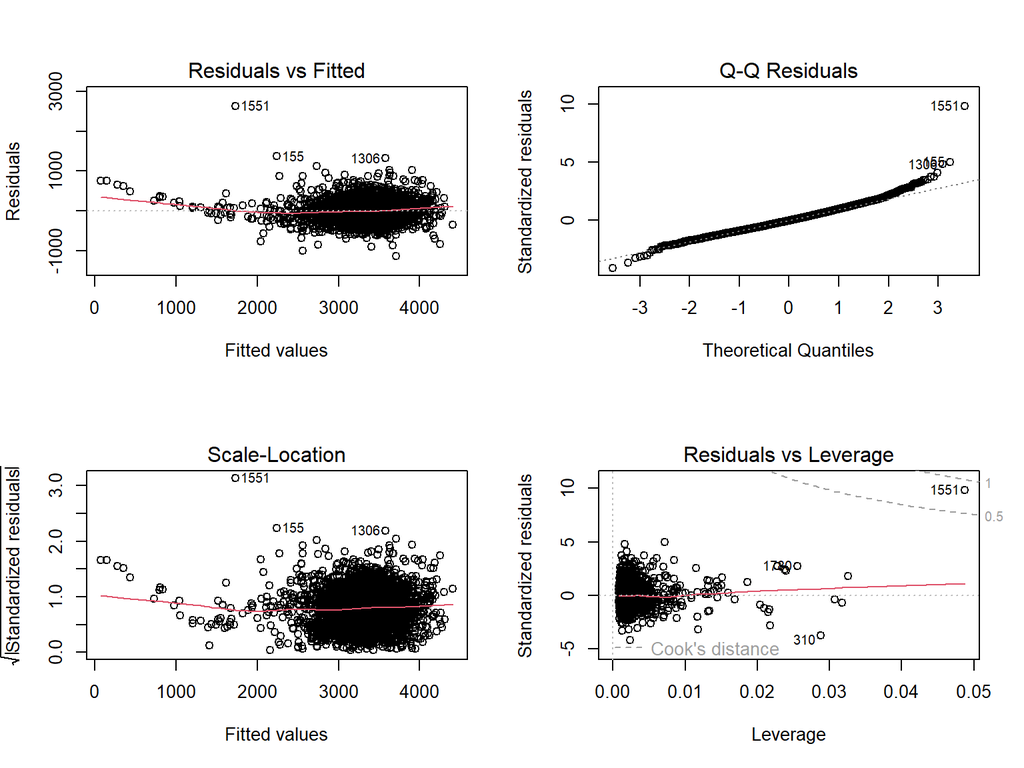

```r
par(mfrow=c(2,2))
plot(model_3)
```

- **Residuals Vs Fitted:** residuals in the plot are randomly distributed around zero and show no funnel shapes or anomalous/systematic patterns so the assumptions of linearity and homoscedasticity of the residuals appear satisfied;
- **Q-Q Residuals:** Residuals should align along the dashed diagonal to satisfy normality; the tails tend to deviate from the line, so we will perform a Shapiro test for confirmation;
- **Scale-Location:** Points are again randomly distributed without funneling or systematic patterns, so the constant variance assumption for the residuals is respected;
- **Residuals vs Leverage:** As observed in the other plots we have potential outliers; however only observation 1551 appears potentially problematic because it exceeds the first warning threshold of 0.5 and approaches 1.

Let’s perform the Shapiro test on the residuals to verify the normality of the residuals’ distribution.

```r
shapiro.test(residuals(model_3))
```

```
##
##  Shapiro-Wilk normality test
##
## data:  residuals(model_3)
## W = 0.97408, p-value < 2.2e-16
```

With a p-value practically equal to zero and a W of 0.97, the Shapiro test suggests rejecting H0 and therefore not considering the residual distribution as normal.

However we will also have a graphical check to be certain that no further action is necessary.

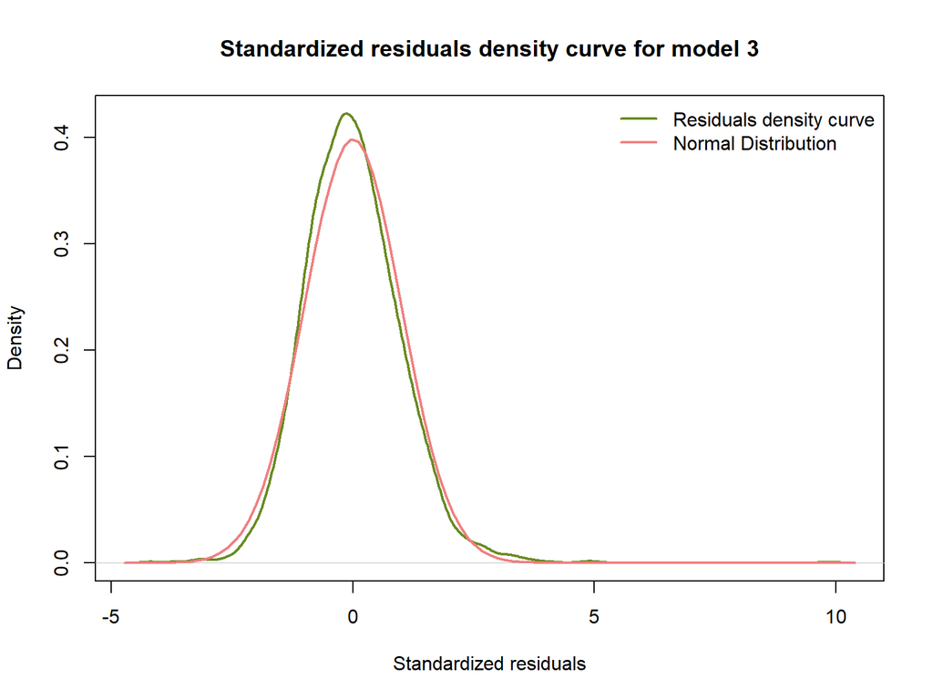

```r
residuals_3 = rstandard(model_3)

plot(
  density(residuals_3),
  main = "Standardized residuals density curve for model 3",
  xlab = "Standardized residuals",
  ylab = "Density",
  col = "olivedrab4",
  lwd = 2
)

curve(
  dnorm(x, mean = mean(residuals_3), sd = sd(residuals_3)),
  col = "lightcoral",
  lwd = 2,
  add = TRUE
  )

legend("topright",
       inset = c(0, 0),
       legend = c("Residuals density curve", "Normal Distribution"),
       col = c("olivedrab4", "lightcoral"),
       lwd = 2,
       bty = "n"
       )
```

We plot a normal distribution in red while in green the residuals’ density curve for model 3. The residual curve is leptokurtic but does not appear to deviate substantially from a normal distribution, so we will proceed without making changes for now.

To verify homoscedasticity assumption of the residuals, which did not appear visually violated, we perform a Breusch-Pagan test.

```r
lmtest::bptest(model_3)
```

```
##
##  studentized Breusch-Pagan test
##
## data:  model_3
## BP = 90.253, df = 5, p-value < 2.2e-16
```

With such a low p-value and a BP of 90.25, the test leads us to reject H0 hypothesis of homoscedasticity and suggests heteroscedasticity.

It is possible that invidividual predictor variables with specific residual distribution patterns are influencing the BP. Based on previous analyses, we hypothesize that these may be the variables Gestation and N.gravidanze.

We will verify below.

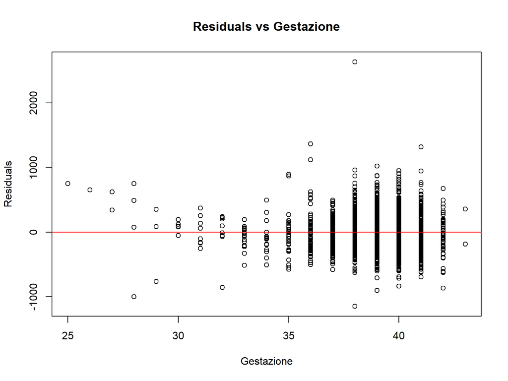

```r
plot(neonatalcare_data$Gestazione, resid(model_3),
     main = "Residuals vs Gestazione",
     xlab = "Gestazione", ylab = "Residuals")
abline(h = 0, col = "red")
```

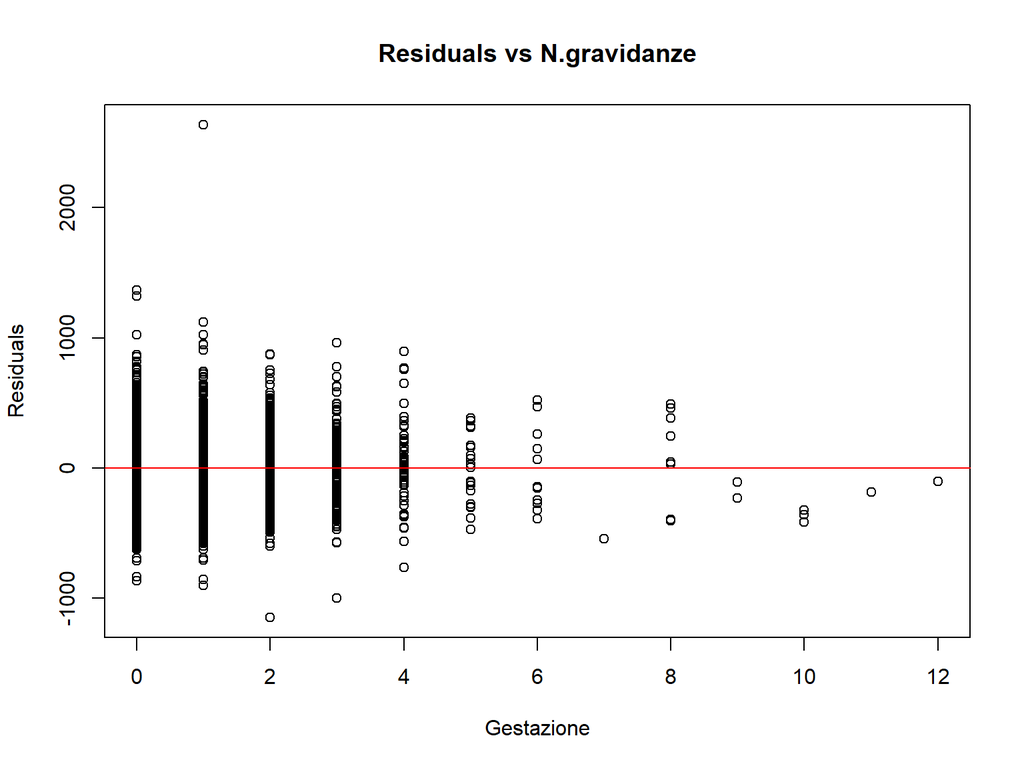

```r
plot(neonatalcare_data$N.gravidanze, resid(model_3),
     main = "Residuals vs N.gravidanze",
     xlab = "Gestazione", ylab = "Residuals")
abline(h = 0, col = "red")
```

As observed in the chart, the two variables have residuals that display specific non-random patterns around zero, suggesting non-constant variance due to the absence of the random residual distribution pattern required by the test; additionally, they tend to increase or decrease with a funnel shape. We can therefore hypothesize that Gestation and N.gravidanze are influencing the BP test results and indicating heteroscedasticity.

We will now perform checks on the outlier values noted during the preliminary residual analysis. We will begin with the outlier value analysis.

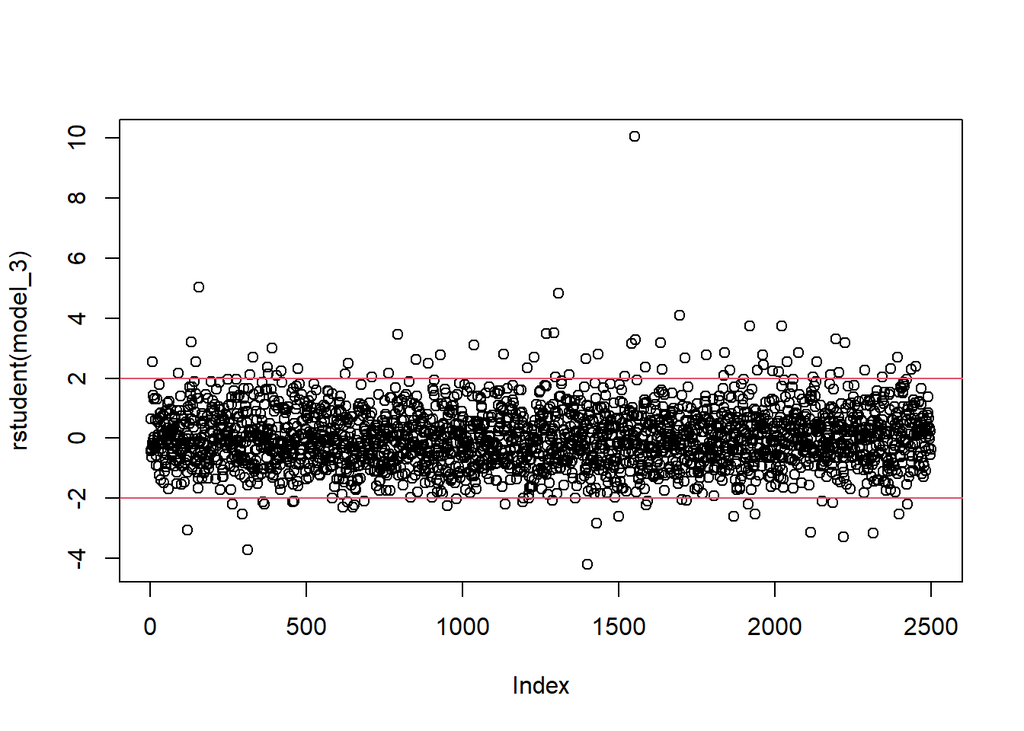

```r
plot(rstudent(model_3))
abline(h=c(-2,2), col=2)
```

```r
car::outlierTest(model_3)
```

```
##       rstudent unadjusted p-value Bonferroni p
## 1551 10.051908         2.4906e-23   6.2265e-20
## 155   5.027798         5.3138e-07   1.3285e-03
## 1306  4.827238         1.4681e-06   3.6702e-03
```

As shown by our OutlierTest, observations 1551, 155 and 1306 can be considered outliers. Of these, only 1551 is extremely significant and potentially highly influential, while 155 and 1306 are less extreme but still relevant.

The plot highlights 1551 clearly; however there are no specific patterns, the randomness around zero is respected and we do not observe systematic patterns or clusters of outliers beyond the thresholds, they do not form a subpopulation so we do not believe there are prediction problems in the model.

Let’s check Cook’s distance more closely now.

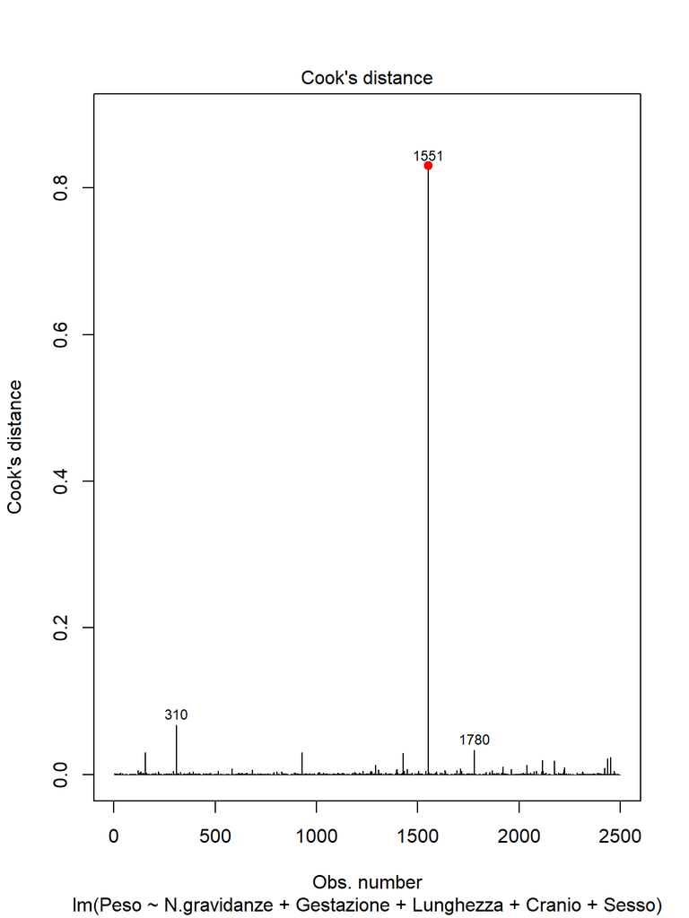

```r
plot(model_3, which = 4)
points(1551, cooks.distance(model_3)[1551], col = "red", pch = 19)
```

```r
cook = cooks.distance(model_3)
cookframe = data.frame(Cooks_max_distance = max(cook))
knitr::kable((cookframe), "pipe")
```

| Cooks_max_distance |
| --- |
| 0.8300965 |

Thanks to this second plot we confirm that 1551 is the only outlier that exceeds the 0.5 warning threshold, reaching a Cook’s distance of 0.83, which places it very close to the critical threshold of 1.

Let’s perform a visual inspection of the outlier observations to determine whether there may be data entry or insertion issues in the dataset.

```r
my_outliers = neonatalcare_data[c(1551,155,1306),]
knitr::kable((my_outliers), "pipe")
```

|  | Anni.madre | N.gravidanze | Fumatrici | Gestazione | Peso | Lunghezza | Cranio | Tipo.parto | Ospedale | Sesso |
| --- | --- | --- | --- | --- | --- | --- | --- | --- | --- | --- |
| 1551 | 35 | 1 | 0 | 38 | 4370 | 315 | 374 | Nat | osp3 | F |
| 155 | 30 | 0 | 0 | 36 | 3610 | 410 | 330 | Nat | osp1 | M |
| 1306 | 23 | 0 | 0 | 41 | 4900 | 510 | 352 | Nat | osp2 | F |

Compared to the dataset’s typical means, 1551 appears to have a neonatal length that is too short for a weight of 4370g. Likewise, 155 shows a length well below the previously observed mean for that variable, thus anomalous, despite a weight that is above the variable’s mean. All of this occurs for a gestational age one week below the threshold normally considered prenatal.

It is plausible that these are erroneous measurements; therefore we will keep them in the dataset because they appear to be isolated cases and are not likely to invalidate the work done so far.

However **this is a hypothesis based on our opinion,**, and consultation with medical staff is recommended to verify whether cases with these statistical values could in fact occur in reality.

At this point we only have to assess the residual autocorrelation of the model variables to confirm the independence assumption.

```r
lmtest::dwtest(model_3)
```

```
##
##  Durbin-Watson test
##
## data:  model_3
## DW = 1.9535, p-value = 0.1224
## alternative hypothesis: true autocorrelation is greater than 0
```

The DW test suggests a slight positive autocorrelation among the variables, but since it is very close to two we are not concerned because we are essentially at an optimal value. The p-value of 0.12 also leads us not to reject the null hypothesis H0 of independent residuals. There is insufficient evidence to refute the assumption and invalidate the model.

## **Use of the created model for statistical predictions**

We now only need to use Model 3 to make statistical predictions of the mean birth weight of newborns, conditional to other variables.

Let’s proceed to verify what the mean birth weight would be for a newborn female with:

- Non-smoker mother;
- Three previous pregnancies;
- Thirthy-ninth week of gestation;

```r
forecast = predict(
  model_3,
  newdata = data.frame(
    Sesso = "F",
    N.gravidanze = 3,
    Gestazione = 39,
    Fumatrici = 0,
    Lunghezza = round(mean(Lunghezza), 2),
    Cranio = round(mean(Cranio), 2)
    )
  )

forecast_data = data.frame (
  Previsione = forecast,
  Sesso = "F",
  N.gravidanze = 3,
  Gestazione = 39,
  Fumatrici = 0,
  Lunghezza_media = round(mean(Lunghezza), 2),
  Cranio_medio = round(mean(Cranio), 2)
)

knitr::kable(forecast_data)
```

| Previsione | Sesso | N.gravidanze | Gestazione | Fumatrici | Lunghezza_media | Cranio_medio |
| --- | --- | --- | --- | --- | --- | --- |
| 3271.078 | F | 3 | 39 | 0 | 494.69 | 340.03 |

Our model estimates that, under the conditions listed above, the newborn female would weigh 3271.08g. To obtain this result we set Length and Head circumference to the distribution means, rounded to two decimal places.

We will run two additional tests with different inputs to observe how the model behaves in prediction.

These cases however, we will compute the expected values of Head circumference and Length based on the desired gestational weeks, so as not to bias any predictive attempt by always using the mean values mentioned above.

We will also compute mean length and head circumference for the specified gestational weeks separately by sex, since we established that birth weight differences between male and female newborns are statistically significant and cannot be ignored, and this may in turn affect the average body dimensions of the newborn at birth.

```r
mean_gestazione = mean(Gestazione, na.rm=T)
mean_lunghezza_M = mean(Lunghezza[Sesso == "M"], na.rm = TRUE)
mean_cranio_M = mean(Cranio[Sesso == "M"], na.rm = TRUE)

mean_lunghezza_F = mean(Lunghezza[Sesso == "F"], na.rm = TRUE)
mean_cranio_F = mean(Cranio[Sesso == "F"], na.rm = TRUE)

n_gestazione = 35
lunghezza_forecast_M = round((n_gestazione / mean_gestazione) * mean_lunghezza_M, 2)
cranio_forecast_M = round((n_gestazione / mean_gestazione) * mean_cranio_M, 2)

lunghezza_forecast_F = round((n_gestazione / mean_gestazione) * mean_lunghezza_F, 2)
cranio_forecast_F = round((n_gestazione / mean_gestazione) * mean_cranio_F, 2)

forecast_2 = predict(
  model_3,
  newdata = data.frame(
    Sesso = "M",
    N.gravidanze = 0,
    Gestazione = n_gestazione,
    Fumatrici = 1,
    Lunghezza = lunghezza_forecast_M,
    Cranio = cranio_forecast_M
  )
)

forecast_data2 = data.frame (
  Previsione = forecast_2,
  Sesso = "M",
  N.gravidanze = 0,
  Gestazione = n_gestazione,
  Fumatrici = 1,
  Lunghezza_media = lunghezza_forecast_M,
  Cranio_medio = cranio_forecast_M
)

forecast_3 = predict(
  model_3,
  newdata = data.frame(
    Sesso = "F",
    N.gravidanze = 0,
    Gestazione = n_gestazione,
    Fumatrici = 1,
    Lunghezza = lunghezza_forecast_F,
    Cranio = cranio_forecast_F
  )
)

forecast_data3 = data.frame (
  Previsione = forecast_3,
  Sesso = "F",
  N.gravidanze = 0,
  Gestazione = n_gestazione,
  Fumatrici = 1,
  Lunghezza_media = lunghezza_forecast_F,
  Cranio_medio = cranio_forecast_F
)

knitr::kable(forecast_data2)
```

| Previsione | Sesso | N.gravidanze | Gestazione | Fumatrici | Lunghezza_media | Cranio_medio |
| --- | --- | --- | --- | --- | --- | --- |
| 2367.287 | M | 0 | 35 | 1 | 448.64 | 307.48 |

```r
knitr::kable(forecast_data3)
```

| Previsione | Sesso | N.gravidanze | Gestazione | Fumatrici | Lunghezza_media | Cranio_medio |
| --- | --- | --- | --- | --- | --- | --- |
| 2152.651 | F | 0 | 35 | 1 | 439.75 | 303.16 |

According to the model, a preterm newborn at 35 weeks born to a smoker mother with zero previous pregnancies is estimated to weigh 2367.287g for males and 2152.651g for females. Now we’ll repeat the same prediction as before, distinguishing between males and females.

```r
n_gestazione = 39
lunghezza_forecast_M = round((n_gestazione / mean_gestazione) * mean_lunghezza_M, 2)
cranio_forecast_M = round((n_gestazione / mean_gestazione) * mean_cranio_M, 2)

lunghezza_forecast_F = round((n_gestazione / mean_gestazione) * mean_lunghezza_F, 2)
cranio_forecast_F = round((n_gestazione / mean_gestazione) * mean_cranio_F, 2)

forecast_4 = predict(
  model_3,
  newdata = data.frame(
    Sesso = "M",
    N.gravidanze = 3,
    Gestazione = n_gestazione,
    Fumatrici = 0,
    Lunghezza = lunghezza_forecast_M,
    Cranio = cranio_forecast_M
  )
)

forecast_data4 = data.frame (
  Previsione = forecast_4,
  Sesso = "M",
  N.gravidanze = 3,
  Gestazione = n_gestazione,
  Fumatrici = 0,
  Lunghezza_media = lunghezza_forecast_M,
  Cranio_medio = cranio_forecast_M
)

forecast_5 = predict(
  model_3,
  newdata = data.frame(
    Sesso = "F",
    N.gravidanze = 3,
    Gestazione = n_gestazione,
    Fumatrici = 0,
    Lunghezza = lunghezza_forecast_F,
    Cranio = cranio_forecast_F
  )
)

forecast_data5 = data.frame (
  Previsione = forecast_5,
  Sesso = "F",
  N.gravidanze = 3,
  Gestazione = n_gestazione,
  Fumatrici = 0,
  Lunghezza_media = lunghezza_forecast_F,
  Cranio_medio = cranio_forecast_F
)

knitr::kable(forecast_data4)
```

| Previsione | Sesso | N.gravidanze | Gestazione | Fumatrici | Lunghezza_media | Cranio_medio |
| --- | --- | --- | --- | --- | --- | --- |
| 3429.97 | M | 3 | 39 | 0 | 499.92 | 342.62 |

```r
knitr::kable(forecast_data5)
```

| Previsione | Sesso | N.gravidanze | Gestazione | Fumatrici | Lunghezza_media | Cranio_medio |
| --- | --- | --- | --- | --- | --- | --- |
| 3199.61 | F | 3 | 39 | 0 | 490.01 | 337.8 |

We will make three more predictions for 41 weeks of gestation.

```r
n_gestazione = 41
lunghezza_forecast_M = round((n_gestazione / mean_gestazione) * mean_lunghezza_M, 2)
cranio_forecast_M = round((n_gestazione / mean_gestazione) * mean_cranio_M, 2)

lunghezza_forecast_F = round((n_gestazione / mean_gestazione) * mean_lunghezza_F, 2)
cranio_forecast_F = round((n_gestazione / mean_gestazione) * mean_cranio_F, 2)

forecast_6 = predict(
  model_3,
  newdata = data.frame(
    Sesso = "M",
    N.gravidanze = 1,
    Gestazione = n_gestazione,
    Fumatrici = 0,
    Lunghezza = lunghezza_forecast_M,
    Cranio = cranio_forecast_M
  )
)

forecast_data6 = data.frame (
  Previsione = forecast_6,
  Sesso = "M",
  N.gravidanze = 1,
  Gestazione = n_gestazione,
  Fumatrici = 0,
  Lunghezza_media = lunghezza_forecast_M,
  Cranio_medio = cranio_forecast_M
)

forecast_7 = predict(
  model_3,
  newdata = data.frame(
    Sesso = "F",
    N.gravidanze = 1,
    Gestazione = n_gestazione,
    Fumatrici = 0,
    Lunghezza = lunghezza_forecast_M,
    Cranio = cranio_forecast_M
  )
)

forecast_data7 = data.frame (
  Previsione = forecast_7,
  Sesso = "F",
  N.gravidanze = 2,
  Gestazione = n_gestazione,
  Fumatrici = 0,
  Lunghezza_media = lunghezza_forecast_M,
  Cranio_medio = cranio_forecast_M
)

forecast_8 = predict(
  model_3,
  newdata = data.frame(
    Sesso = "M",
    N.gravidanze = 6,
    Gestazione = n_gestazione,
    Fumatrici = 1,
    Lunghezza = lunghezza_forecast_M,
    Cranio = cranio_forecast_M
  )
)

forecast_data8 = data.frame (
  Previsione = forecast_8,
  Sesso = "M",
  N.gravidanze = 6,
  Gestazione = n_gestazione,
  Fumatrici = 1,
  Lunghezza_media = lunghezza_forecast_M,
  Cranio_medio = cranio_forecast_M
)

knitr::kable(forecast_data6)
```

| Previsione | Sesso | N.gravidanze | Gestazione | Fumatrici | Lunghezza_media | Cranio_medio |
| --- | --- | --- | --- | --- | --- | --- |
| 3917.648 | M | 1 | 41 | 0 | 525.56 | 360.19 |

```r
knitr::kable(forecast_data7)
```

[output not shown]

```r
knitr::kable(forecast_data8)
```

| Previsione | Sesso | N.gravidanze | Gestazione | Fumatrici | Lunghezza_media | Cranio_medio |
| --- | --- | --- | --- | --- | --- | --- |
| 3980.023 | M | 6 | 41 | 1 | 525.56 | 360.19 |

After running some predictive tests with our model we check whether it is possible to visually demonstrate its overall predictive performance as well as the partial relationship between Weight and the predictors included in the model.

#### **Model predictive-performance plots.**

Before comparing the relationship between the observed values in the dataset and those predicted by our model, we can get a clearer idea of how the variables affect the model’s predictive ability through these **partial dependence plot**.

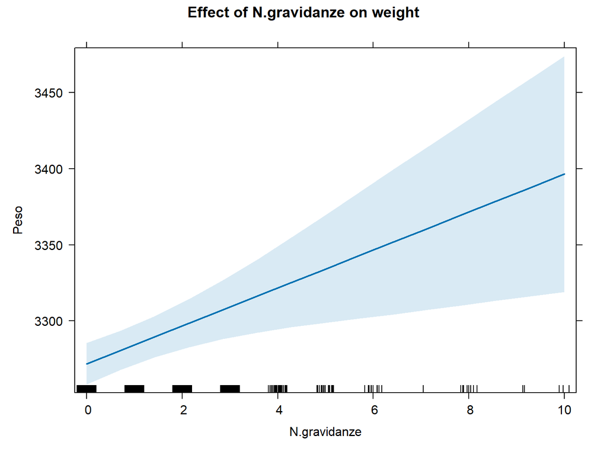

```r
library("effects")
eff = allEffects(model_3)

plot(eff, "N.gravidanze", main = "Effect of N.gravidanze on weight")
```

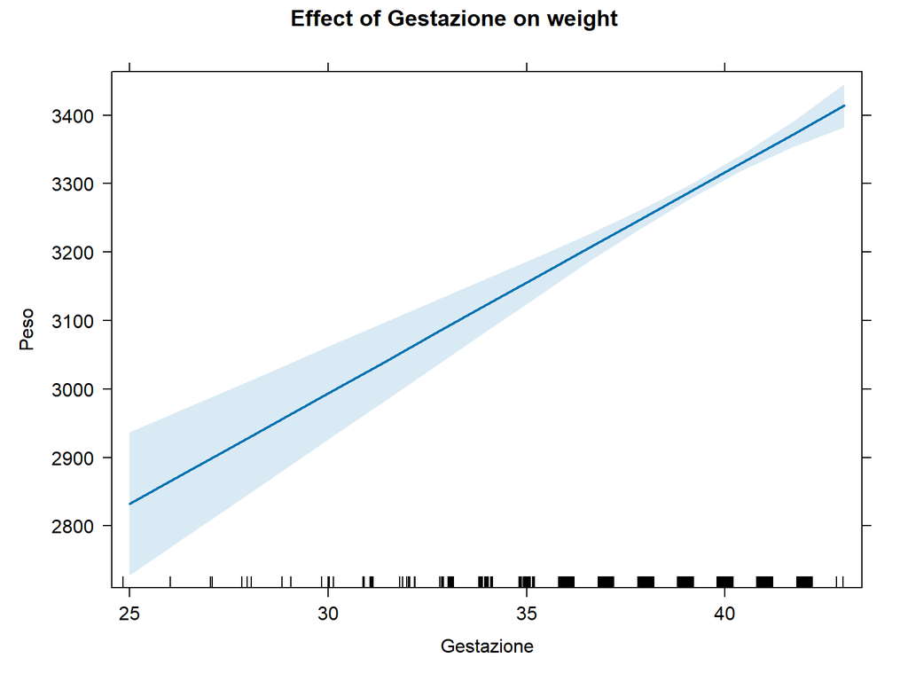

```r
plot(eff, "Gestazione", main = "Effect of Gestazione on weight")
```

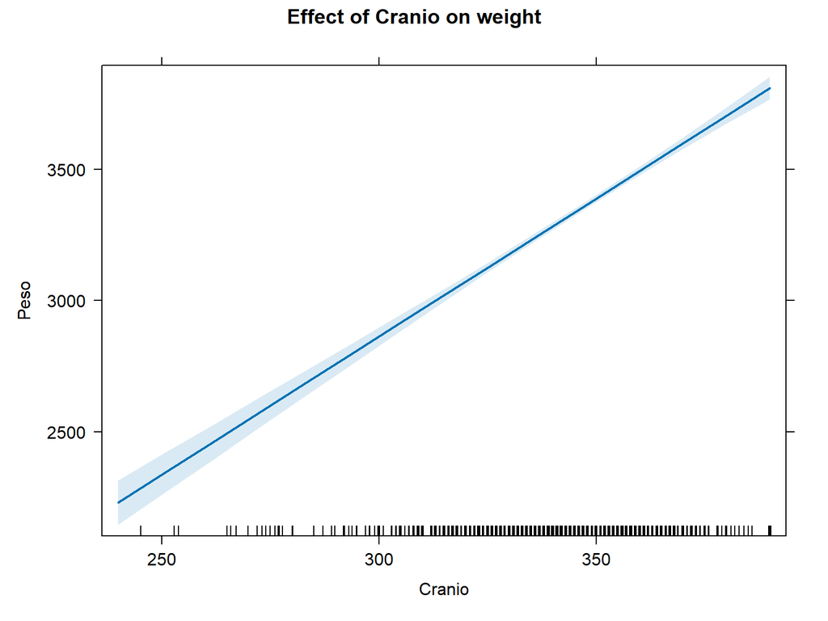

```r
plot(eff, "Cranio", main = "Effect of Cranio on weight")
```

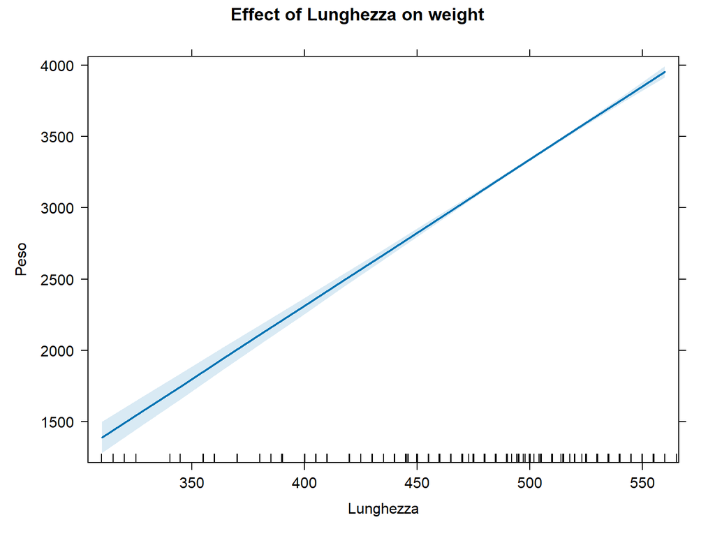

```r
plot(eff, "Lunghezza", main = "Effect of Lunghezza on weight")
```